# Introduction to Open Data Science 2022 - Course Diary

Jaana Kuoppala

# Getting started

```r
date()
```

```
## [1] "Thu Nov 17 21:23:44 2022"
```

This IODS2022 is an introductory course to open data science and the open tools commonly used in it.

Link to my GitHub repository: https://github.com/jmleppal/IODS-project

I went through the R for the Health Data Science and got a some grasp on elementary use of R. All in all, the book is an excellent introduction to this topic. I’m trying to understand the intestines of GitHub but at the moment it looks to me as a long path of trial and error. When it comes to R Markdown, working on this visual-mode seems to be easier now in the beginning.

# Regression and model validation

```r
date()
```

```
## [1] "Thu Nov 17 21:23:44 2022"
```

```r
# READING IN THE ORIGINAL DATASET

# Read the data into memory
learning2014 <- read.table("http://www.helsinki.fi/~kvehkala/JYTmooc/JYTOPKYS3-data.txt", sep="\t", header=TRUE)

# Look at the dimensions and structure of the data
dim(learning2014)
```

```
## [1] 183  60
```

```r
# str(learning2014)
```

The dataset used in this exercise is based on an international survey of students’ approaches to learning in 2013-2015. Measures in the parts A, B and C come from the ASSIST (Approaches and Study Skills Inventory for Students) questionnaire and the part D is based on the SATS (Survey of Attitudes Toward Statistics) questionnaire. Some background and other variables have been omitted, but all 183 responses are included. So all in all, there are 60 variables and 183 observations included. All variables except the one on gender are integers. No values are missing.

```r
# CREATING THE ANALYSIS DATASET

# Access the dplyr library
library(dplyr)
# Create an analysis dataset
deep_questions <- c("D03", "D11", "D19", "D27", "D07", "D14", "D22", "D30","D06",  "D15", "D23", "D31")
surface_questions <- c("SU02","SU10","SU18","SU26", "SU05","SU13","SU21","SU29","SU08","SU16","SU24","SU32")
strategic_questions <- c("ST01","ST09","ST17","ST25","ST04","ST12","ST20","ST28")

learn2014an <- learning2014 %>% select(gender, Age, Points)
learn2014an$deep <- rowMeans(learning2014[, deep_questions])
learn2014an$surf <- rowMeans(learning2014[, surface_questions])
learn2014an$stra <- rowMeans(learning2014[, strategic_questions])

# create the column 'attitude' by scaling the column "Attitude"
learn2014an$attitude <- learning2014$Attitude / 10

# print out the column names of the data
colnames(learn2014an)
```

```
## [1] "gender"   "Age"      "Points"   "deep"     "surf"     "stra"     "attitude"
```

```r
# change the names of certain columns
colnames(learn2014an)[2] <- "age"
colnames(learn2014an)[3] <- "points"

# select rows where points is greater than zero
learn2014an <- filter(learn2014an, points > 0)

# Look at the dimensions and structure of the analysis data
# dim(learn2014an)
str(learn2014an)
```

```
## 'data.frame':    166 obs. of  7 variables:
##  $ gender  : chr  "F" "M" "F" "M" ...
##  $ age     : int  53 55 49 53 49 38 50 37 37 42 ...
##  $ points  : int  25 12 24 10 22 21 21 31 24 26 ...
##  $ deep    : num  3.58 2.92 3.5 3.5 3.67 ...
##  $ surf    : num  2.58 3.17 2.25 2.25 2.83 ...
##  $ stra    : num  3.38 2.75 3.62 3.12 3.62 ...
##  $ attitude: num  3.7 3.1 2.5 3.5 3.7 3.8 3.5 2.9 3.8 2.1 ...
```

In the analysis dataset, variables on gender, age and points are unmodified but the variable on attitude is modified by dividing the original one by 10, and new variables deep, surf and stra are formed by averaging the respective part B variables. Attitude measures the global attitude towards statistics. Deep is a measure on how inclined the participant is towards deep learning, surf is a measure on how superficially the participant approaches his or her studying, and stra is a measure on how organized the participant’s manner is in studying. Points are the points obtained in an exam in a course on Introduction to Social Statistics.

The value 0 in points actually means that the participant did not participate in the exam (n = 17, 9%). These participants are excluded from the analysis dataset. Thus the dataset consists of 7 variables and 166 observations.

```r
# SAVING THE ANALYSIS DATASET AND CHECKING THAT READING ANEW WORKS

# Set the working directory for saving and data
setwd("C:/Users/yona2/Desktop/FT/IODS2022/RStudio/IODS-project/data")

# Access the tidyverse library
library(tidyverse)
# Save the analysis dataset
write.csv(learn2014an,"learn2014an.csv", row.names = FALSE)

# Checking that reading of the saved file works
# learn2014an2 <- read.table("learn2014an.csv", sep=",", header=TRUE)
# str(learn2014an2)
# head(learn2014an2)
```

Saving and reading the saved file work as expected.

```r
# EXPLORING THE ANALYSIS DATA

# Access the GGally, ggplot2 and cowplot libraries
library(GGally)
library(ggplot2)

# Get summary values
learn2014an %>% group_by(gender) %>% summarise(count= n())
```

```
## # A tibble: 2 × 2
##   gender count
##   <chr>  <int>
## 1 F        110
## 2 M         56
```

```r
summarise_at(learn2014an, vars(attitude:points), tibble::lst(mean, sd))
```

```
##   attitude_mean stra_mean surf_mean deep_mean points_mean attitude_sd   stra_sd
## 1      3.142771  3.121235  2.787149  3.679719    22.71687   0.7299079 0.7718318
##     surf_sd   deep_sd points_sd
## 1 0.5288405 0.5541369  5.894884
```

```r
learn2014an %>% group_by(gender) %>% summarise_at(vars(age), tibble::lst(mean, sd, min, median, max))
```

```
## # A tibble: 2 × 6
##   gender  mean    sd   min median   max
##   <chr>  <dbl> <dbl> <int>  <dbl> <int>
## 1 F       24.9  7.36    17     22    53
## 2 M       26.8  8.43    19     24    55
```

```r
learn2014an %>% group_by(gender) %>% summarise_at(vars(attitude), tibble::lst(mean, sd, min, median, max))
```

```
## # A tibble: 2 × 6
##   gender  mean    sd   min median   max
##   <chr>  <dbl> <dbl> <dbl>  <dbl> <dbl>
## 1 F       2.99 0.725   1.4   2.95   5
## 2 M       3.44 0.646   1.7   3.4    4.8
```

```r
learn2014an %>% group_by(gender) %>% summarise_at(vars(deep), tibble::lst(mean, sd, min, median, max))
```

```
## # A tibble: 2 × 6
##   gender  mean    sd   min median   max
##   <chr>  <dbl> <dbl> <dbl>  <dbl> <dbl>
## 1 F       3.66 0.535  1.58   3.67  4.75
## 2 M       3.72 0.592  2.08   3.79  4.92
```

```r
learn2014an %>% group_by(gender) %>% summarise_at(vars(surf), tibble::lst(mean, sd, min, median, max))
```

```
## # A tibble: 2 × 6
##   gender  mean    sd   min median   max
##   <chr>  <dbl> <dbl> <dbl>  <dbl> <dbl>
## 1 F       2.83 0.458  1.83   2.83  4
## 2 M       2.70 0.642  1.58   2.62  4.33
```

```r
learn2014an %>% group_by(gender) %>% summarise_at(vars(stra), tibble::lst(mean, sd, min, median, max))
```

```
## # A tibble: 2 × 6
##   gender  mean    sd   min median   max
##   <chr>  <dbl> <dbl> <dbl>  <dbl> <dbl>
## 1 F       3.20 0.748  1.38   3.25   5
## 2 M       2.96 0.801  1.25   3      4.5
```

```r
learn2014an %>% group_by(gender) %>% summarise_at(vars(points), tibble::lst(mean, sd, min, median, max))
```

```
## # A tibble: 2 × 6
##   gender  mean    sd   min median   max
##   <chr>  <dbl> <dbl> <int>  <dbl> <int>
## 1 F       22.3  5.83     7   23      33
## 2 M       23.5  6.01     9   23.5    33
```

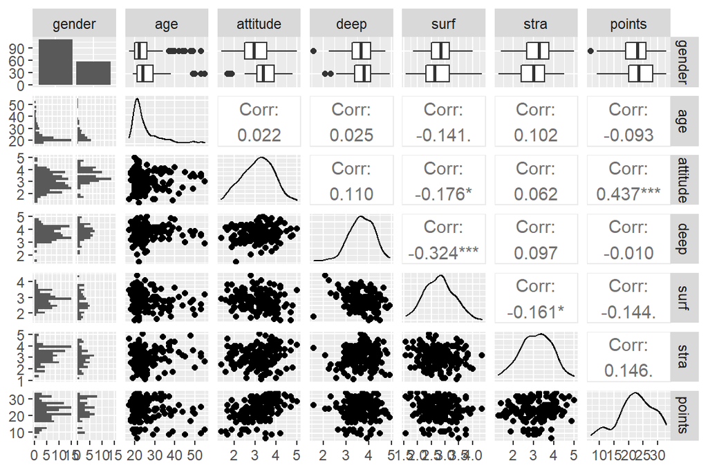

```r
# Create and draw a more advanced plot matrix with ggpairs()
p <- ggpairs(learn2014an[, c(1, 2, 7, 4, 5, 6, 3)], mapping = aes(), lower = list(combo = wrap("facethist", bins = 20)), progress = FALSE)
p
```

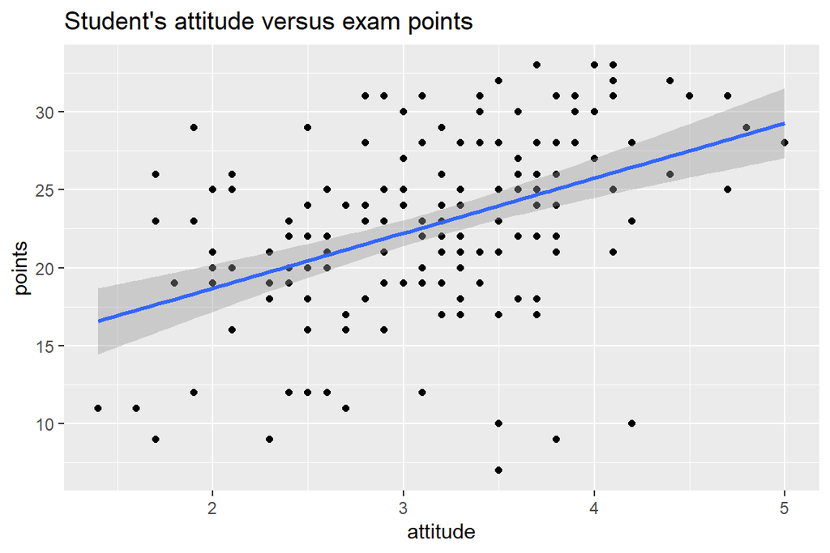

```r
# Initialize plot with data and aesthetic mapping
p1 <- ggplot(learn2014an, aes(x = attitude, y = points))

# Define the visualization type (points) + add a regression line
# + add a main title and draw the plot
p2 <- p1 + geom_point() + geom_smooth(method = "lm") + ggtitle("Student's attitude versus exam points")
p2
```

Out of 166 participants, 56 (34%) are men and 110 (66%) women. The age ranges from 17 to 55 years, the average age (sd) being 26.8 (8.4) years for men and 24.9 (7.4) years for women. Mean scores (sd) are 3.1 (0.7) for attitude, 3.7 (0.6) for deep, 2.8 (0.5) for surf, 3.1 (0.8) for stra and 22.7 (5.9) for points. The distribution of age is skewed to the right, otherwise the distributions are reasonably symmetrical and do not noteworthy differ between gender.

Attitude is significantly correlated with points (rho = 0.44), which association can be seen nicely in the respective plot. On the other hand, surf is slightly negatively (rho -0.14) and stra slightly positively (rho = 0.15) correlated with points, as expected. There is statistically significant negative correlation between surf and attitude (rho = -0.18), deep (rho = -0.32) and stra (rho = -0.16), as expected. Otherwise the associations are unremarkable.

```r
# BUILDING A MULTIPLE REGRESSION MODEL

# Fit a linear model
my_model1 <- lm(points ~ age, data = learn2014an)
my_model2 <- lm(points ~ gender, data = learn2014an)
my_model3 <- lm(points ~ attitude, data = learn2014an)
my_model4 <- lm(points ~ deep, data = learn2014an)
my_model5 <- lm(points ~ surf, data = learn2014an)
my_model6 <- lm(points ~ stra, data = learn2014an)

my_model31 <- lm(points ~ attitude + stra + surf, data = learn2014an)
my_model32 <- lm(points ~ attitude + age + gender, data = learn2014an)

# Print out a summary of the models
summary(my_model1)
```

```
##
## Call:
## lm(formula = points ~ age, data = learn2014an)
##
## Residuals:
##      Min       1Q   Median       3Q      Max
## -16.0360  -3.7531   0.0958   4.6762  10.8128
##
## Coefficients:
##             Estimate Std. Error t value Pr(>|t|)
## (Intercept) 24.52150    1.57339  15.585   <2e-16 ***
## age         -0.07074    0.05901  -1.199    0.232
## ---
## Signif. codes:  0 '***' 0.001 '**' 0.01 '*' 0.05 '.' 0.1 ' ' 1
##
## Residual standard error: 5.887 on 164 degrees of freedom
## Multiple R-squared:  0.008684,   Adjusted R-squared:  0.00264
## F-statistic: 1.437 on 1 and 164 DF,  p-value: 0.2324
```

```r
summary(my_model2)
```

```
##
## Call:
## lm(formula = points ~ gender, data = learn2014an)
##
## Residuals:
##      Min       1Q   Median       3Q      Max
## -15.3273  -3.3273   0.5179   4.5179  10.6727
##
## Coefficients:
##             Estimate Std. Error t value Pr(>|t|)
## (Intercept)  22.3273     0.5613  39.776   <2e-16 ***
## genderM       1.1549     0.9664   1.195    0.234
## ---
## Signif. codes:  0 '***' 0.001 '**' 0.01 '*' 0.05 '.' 0.1 ' ' 1
##
## Residual standard error: 5.887 on 164 degrees of freedom
## Multiple R-squared:  0.008632,   Adjusted R-squared:  0.002587
## F-statistic: 1.428 on 1 and 164 DF,  p-value: 0.2338
```

```r
summary(my_model3)
```

```
##
## Call:
## lm(formula = points ~ attitude, data = learn2014an)
##
## Residuals:
##      Min       1Q   Median       3Q      Max
## -16.9763  -3.2119   0.4339   4.1534  10.6645
##
## Coefficients:
##             Estimate Std. Error t value Pr(>|t|)
## (Intercept)  11.6372     1.8303   6.358 1.95e-09 ***
## attitude      3.5255     0.5674   6.214 4.12e-09 ***
## ---
## Signif. codes:  0 '***' 0.001 '**' 0.01 '*' 0.05 '.' 0.1 ' ' 1
##
## Residual standard error: 5.32 on 164 degrees of freedom
## Multiple R-squared:  0.1906, Adjusted R-squared:  0.1856
## F-statistic: 38.61 on 1 and 164 DF,  p-value: 4.119e-09
```

```r
summary(my_model4)
```

```
##
## Call:
## lm(formula = points ~ deep, data = learn2014an)
##
## Residuals:
##      Min       1Q   Median       3Q      Max
## -15.6913  -3.6935   0.2862   4.9957  10.3537
##
## Coefficients:
##             Estimate Std. Error t value Pr(>|t|)
## (Intercept)  23.1141     3.0908   7.478 4.31e-12 ***
## deep         -0.1080     0.8306  -0.130    0.897
## ---
## Signif. codes:  0 '***' 0.001 '**' 0.01 '*' 0.05 '.' 0.1 ' ' 1
##
## Residual standard error: 5.913 on 164 degrees of freedom
## Multiple R-squared:  0.000103,   Adjusted R-squared:  -0.005994
## F-statistic: 0.01689 on 1 and 164 DF,  p-value: 0.8967
```

```r
summary(my_model5)
```

```
##
## Call:
## lm(formula = points ~ surf, data = learn2014an)
##
## Residuals:
##      Min       1Q   Median       3Q      Max
## -14.6539  -3.3744   0.3574   4.4734  10.2234
##
## Coefficients:
##             Estimate Std. Error t value Pr(>|t|)
## (Intercept)  27.2017     2.4432  11.134   <2e-16 ***
## surf         -1.6091     0.8613  -1.868   0.0635 .
## ---
## Signif. codes:  0 '***' 0.001 '**' 0.01 '*' 0.05 '.' 0.1 ' ' 1
##
## Residual standard error: 5.851 on 164 degrees of freedom
## Multiple R-squared:  0.02084,    Adjusted R-squared:  0.01487
## F-statistic:  3.49 on 1 and 164 DF,  p-value: 0.06351
```

```r
summary(my_model6)
```

```
##
## Call:
## lm(formula = points ~ stra, data = learn2014an)
##
## Residuals:
##      Min       1Q   Median       3Q      Max
## -16.5581  -3.8198   0.1042   4.3024  10.1394
##
## Coefficients:
##             Estimate Std. Error t value Pr(>|t|)
## (Intercept)   19.233      1.897  10.141   <2e-16 ***
## stra           1.116      0.590   1.892   0.0603 .
## ---
## Signif. codes:  0 '***' 0.001 '**' 0.01 '*' 0.05 '.' 0.1 ' ' 1
##
## Residual standard error: 5.849 on 164 degrees of freedom
## Multiple R-squared:  0.02135,    Adjusted R-squared:  0.01538
## F-statistic: 3.578 on 1 and 164 DF,  p-value: 0.06031
```

```r
summary(my_model31)
```

```
##
## Call:
## lm(formula = points ~ attitude + stra + surf, data = learn2014an)
##
## Residuals:
##      Min       1Q   Median       3Q      Max
## -17.1550  -3.4346   0.5156   3.6401  10.8952
##
## Coefficients:
##             Estimate Std. Error t value Pr(>|t|)
## (Intercept)  11.0171     3.6837   2.991  0.00322 **
## attitude      3.3952     0.5741   5.913 1.93e-08 ***
## stra          0.8531     0.5416   1.575  0.11716
## surf         -0.5861     0.8014  -0.731  0.46563
## ---
## Signif. codes:  0 '***' 0.001 '**' 0.01 '*' 0.05 '.' 0.1 ' ' 1
##
## Residual standard error: 5.296 on 162 degrees of freedom
## Multiple R-squared:  0.2074, Adjusted R-squared:  0.1927
## F-statistic: 14.13 on 3 and 162 DF,  p-value: 3.156e-08
```

```r
summary(my_model32)
```

```
##
## Call:
## lm(formula = points ~ attitude + age + gender, data = learn2014an)
##
## Residuals:
##      Min       1Q   Median       3Q      Max
## -17.4590  -3.3221   0.2186   4.0247  10.4632
##
## Coefficients:
##             Estimate Std. Error t value Pr(>|t|)
## (Intercept) 13.42910    2.29043   5.863 2.48e-08 ***
## attitude     3.60657    0.59322   6.080 8.34e-09 ***
## age         -0.07586    0.05367  -1.414    0.159
## genderM     -0.33054    0.91934  -0.360    0.720
## ---
## Signif. codes:  0 '***' 0.001 '**' 0.01 '*' 0.05 '.' 0.1 ' ' 1
##
## Residual standard error: 5.315 on 162 degrees of freedom
## Multiple R-squared:  0.2018, Adjusted R-squared:  0.187
## F-statistic: 13.65 on 3 and 162 DF,  p-value: 5.536e-08
```

```r
summary(my_model3)
```

```
##
## Call:
## lm(formula = points ~ attitude, data = learn2014an)
##
## Residuals:
##      Min       1Q   Median       3Q      Max
## -16.9763  -3.2119   0.4339   4.1534  10.6645
##
## Coefficients:
##             Estimate Std. Error t value Pr(>|t|)
## (Intercept)  11.6372     1.8303   6.358 1.95e-09 ***
## attitude      3.5255     0.5674   6.214 4.12e-09 ***
## ---
## Signif. codes:  0 '***' 0.001 '**' 0.01 '*' 0.05 '.' 0.1 ' ' 1
##
## Residual standard error: 5.32 on 164 degrees of freedom
## Multiple R-squared:  0.1906, Adjusted R-squared:  0.1856
## F-statistic: 38.61 on 1 and 164 DF,  p-value: 4.119e-09
```

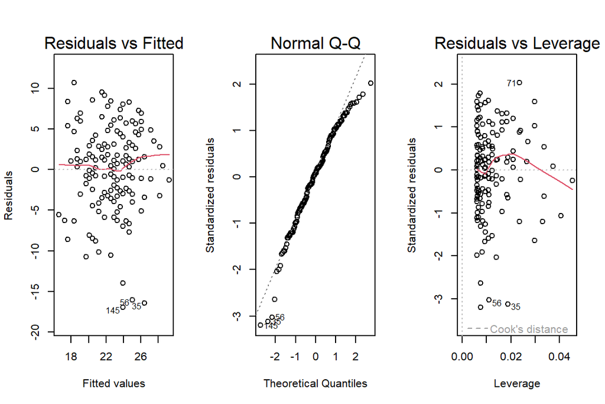

```r
# Draw diagnostic plots using the plot() function, choosing the plots 1, 2 and 5
par(mfrow = c(1,3))
plot(my_model3, which = c(1, 2, 5))
```

In univariate regression models, only attitude has a statistically significant association with points (p = 4.12e-09). Surf and stra are marginally associated with points (p = 0.06 for both).

Attitude, surf and stra are selected as explanatory variables for a multiple regression model. In the model, attitude preserves its statistical significance while surf and stra do not add much to it. The overall fitness of the model do not improve: there is practically no change in multiple R-squared (0.21 in the multiple regression and 0.19 in the univariate model) and the overall p actually worsens (3.16e-08 in the multiple regression and 4.12e-09 in the univariate model). Likewise, adding demographic factors age and gender to the model do not improve it.

Therefore, for the final model, only attitude is selected as an explanatory variable. An increase of one unit in attitude is associated with an increase of 3.5 points in the exam results. Based on the multiple R-squared statistics, scores in attitude explained 19 % of the variation in points. Even though this “explanatory power” is rather small, the model was statistically highly significant (F = 38.6 with 1 and 164 df, p = 4.12e-09). This kind of result is rather typical for human behavioral data.

In a linear regression model, the association between the dependant and explanatory variable are assumed to be linear and monotonously increasing or decreasing. The included variables should be normally distributed and the explanatory variables uncorrelated with each other. The diagnostic plots did not show any noteworthy deviance; there were a couple of outliers that did not seem to distort the association between attitude and points. The distributions of both attitude and points were reasonably symmetrical and close enough to normal. In the scatter plot on points by attitude, the association seemed clearly monotonously increasing.

# Logistic regression

```r
date()
```

```
## [1] "Thu Nov 17 21:23:59 2022"
```

```r
# READING IN THE DATASET

# set the working directory
 setwd("C:/Users/yona2/Desktop/FT/IODS2022/RStudio/IODS-project/data")

# access the tidyverse library
 library(tidyverse)

# read the data
 alc <- read.table("alc.csv", sep = ",", header = TRUE)

# check structure and dimensions
colnames(alc)
```

```
##  [1] "X"          "school"     "sex"        "age"        "address"
##  [6] "famsize"    "Pstatus"    "Medu"       "Fedu"       "Mjob"
## [11] "Fjob"       "reason"     "guardian"   "traveltime" "studytime"
## [16] "schoolsup"  "famsup"     "activities" "nursery"    "higher"
## [21] "internet"   "romantic"   "famrel"     "freetime"   "goout"
## [26] "Dalc"       "Walc"       "health"     "failures"   "paid"
## [31] "absences"   "G1"         "G2"         "G3"         "alc_use"
## [36] "high_use"
```

```r
# glimpse(alc)
```

The data is based on two surveys concerning student achievement in secondary education in two Portuguese schools. The dataset contains factors related to performances in mathematics and Portuguese language. The variables failures, paid, absences, G1, G2 and G3 present a combined assessment on both subjects. The analyses focus on the relationship between alcohol consumption (alc_use; 1 very low to 5 very high) and other variables. Alcohol use is considered high if it exceeds 2 (high_use).

All in all, there are 36 variables and 370 observations included. No values are missing.

As for primary hypotheses, I would expect going out, failures and absences to be positively and final grade (G3) to be negatively associated with alcohol use.

```r
# EXPLORING THE DATA

# access the GGally and ggplot2 libraries
library(GGally); library(ggplot2)

# set summary values
summary(alc[, c(4, 8:9, 14:15, 23:25, 28:29, 31, 34:35)])
```

```
##       age             Medu          Fedu         traveltime      studytime
##  Min.   :15.00   Min.   :0.0   Min.   :0.000   Min.   :1.000   Min.   :1.000
##  1st Qu.:16.00   1st Qu.:2.0   1st Qu.:2.000   1st Qu.:1.000   1st Qu.:1.000
##  Median :17.00   Median :3.0   Median :3.000   Median :1.000   Median :2.000
##  Mean   :16.58   Mean   :2.8   Mean   :2.557   Mean   :1.446   Mean   :2.043
##  3rd Qu.:17.00   3rd Qu.:4.0   3rd Qu.:3.750   3rd Qu.:2.000   3rd Qu.:2.000
##  Max.   :22.00   Max.   :4.0   Max.   :4.000   Max.   :4.000   Max.   :4.000
##      famrel         freetime         goout           health
##  Min.   :1.000   Min.   :1.000   Min.   :1.000   Min.   :1.000
##  1st Qu.:4.000   1st Qu.:3.000   1st Qu.:2.000   1st Qu.:3.000
##  Median :4.000   Median :3.000   Median :3.000   Median :4.000
##  Mean   :3.935   Mean   :3.224   Mean   :3.116   Mean   :3.562
##  3rd Qu.:5.000   3rd Qu.:4.000   3rd Qu.:4.000   3rd Qu.:5.000
##  Max.   :5.000   Max.   :5.000   Max.   :5.000   Max.   :5.000
##     failures         absences            G3           alc_use
##  Min.   :0.0000   Min.   : 0.000   Min.   : 0.00   Min.   :1.000
##  1st Qu.:0.0000   1st Qu.: 1.000   1st Qu.:10.00   1st Qu.:1.000
##  Median :0.0000   Median : 3.000   Median :12.00   Median :1.500
##  Mean   :0.1892   Mean   : 4.511   Mean   :11.52   Mean   :1.889
##  3rd Qu.:0.0000   3rd Qu.: 6.000   3rd Qu.:14.00   3rd Qu.:2.500
##  Max.   :3.0000   Max.   :45.000   Max.   :18.00   Max.   :5.000
```

```r
alc %>% group_by(sex) %>% summarise(count= n())
```

```
## # A tibble: 2 × 2
##   sex   count
##   <chr> <int>
## 1 F       195
## 2 M       175
```

```r
alc %>% group_by(high_use) %>% summarise(count= n())
```

```
## # A tibble: 2 × 2
##   high_use count
##   <lgl>    <int>
## 1 FALSE      259
## 2 TRUE       111
```

```r
alc %>% group_by(sex, high_use) %>% summarise(count= n())
```

[output not shown]

```
## # A tibble: 4 × 3
## # Groups:   sex [2]
##   sex   high_use count
##   <chr> <lgl>    <int>
## 1 F     FALSE      154
## 2 F     TRUE        41
## 3 M     FALSE      105
## 4 M     TRUE        70
```

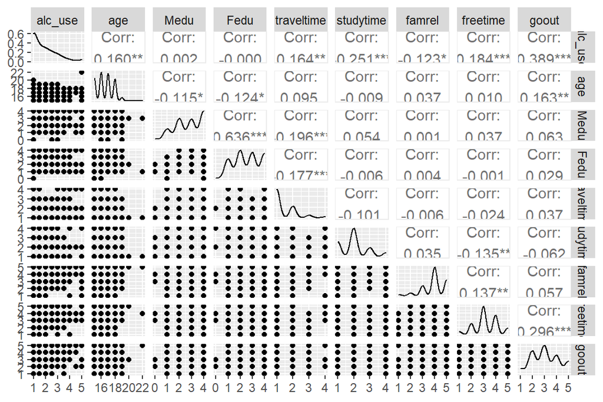

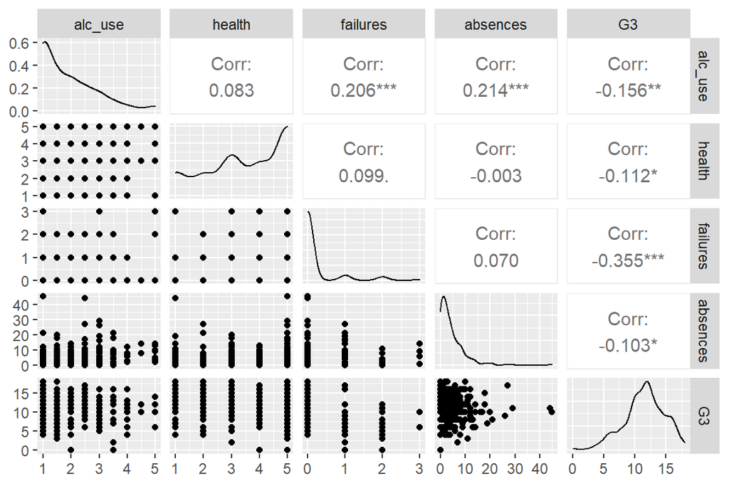

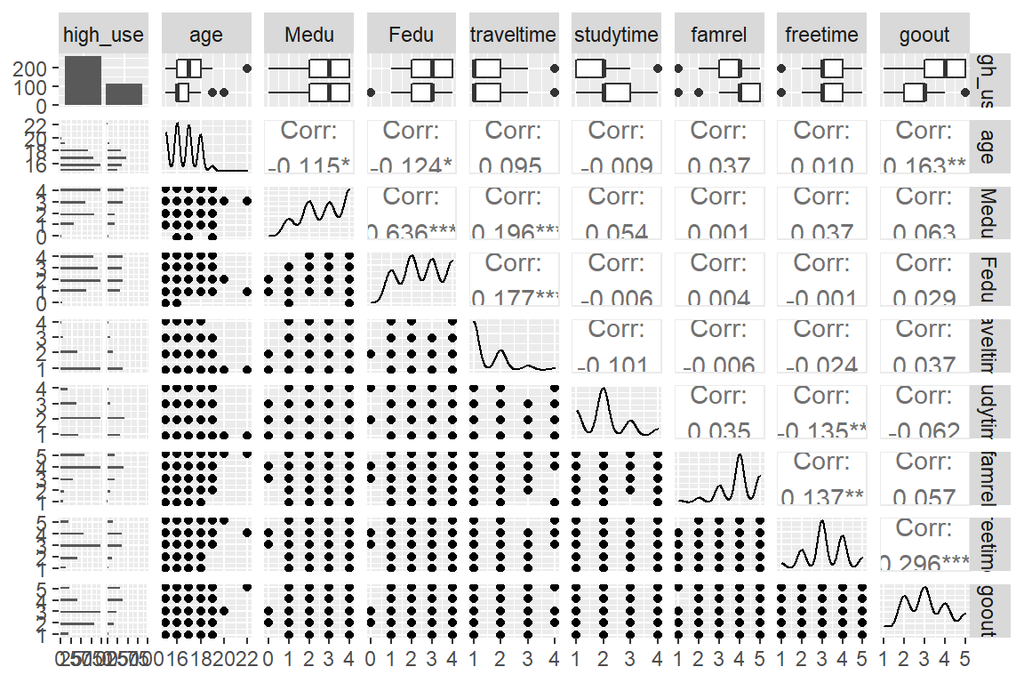

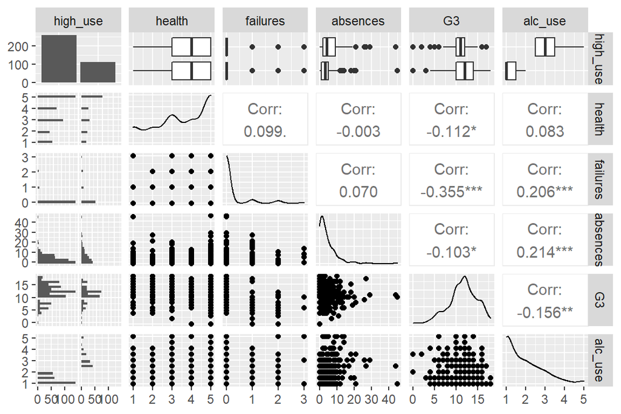

```r
p1 <- ggpairs(alc[, c(35, 4, 8:9, 14:15, 23:25)], mapping = aes(), lower = list(combo = wrap("facethist", bins = 20)), progress = FALSE)
p2 <- ggpairs(alc[, c(35, 28:29, 31, 34)], mapping = aes(), lower = list(combo = wrap("facethist", bins = 20)), progress = FALSE)
p3 <- ggpairs(alc[, c(36, 4, 8:9, 14:15, 23:25)], mapping = aes(), lower = list(combo = wrap("facethist", bins = 20)), progress = FALSE)
p4 <- ggpairs(alc[, c(36, 28:29, 31, 34:35)], mapping = aes(), lower = list(combo = wrap("facethist", bins = 20)), progress = FALSE)
p1; p2; p3; p4
```

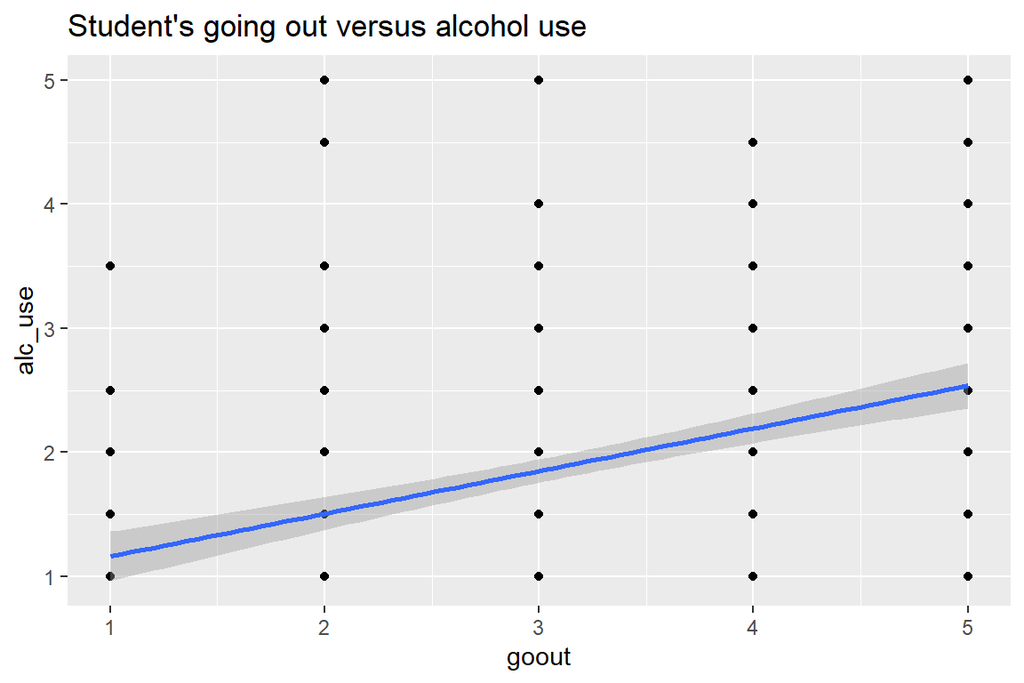

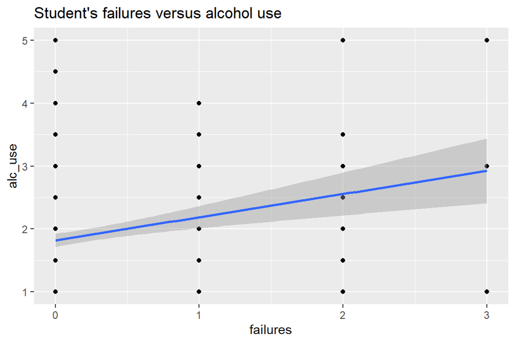

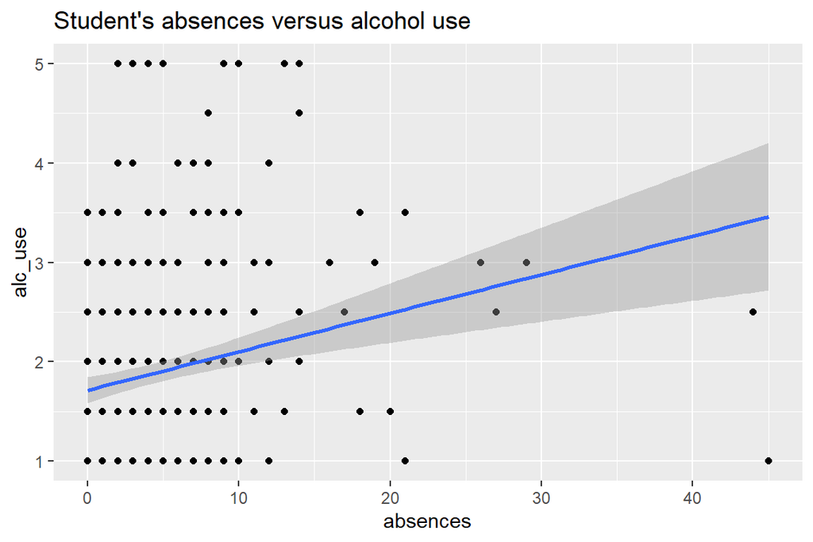

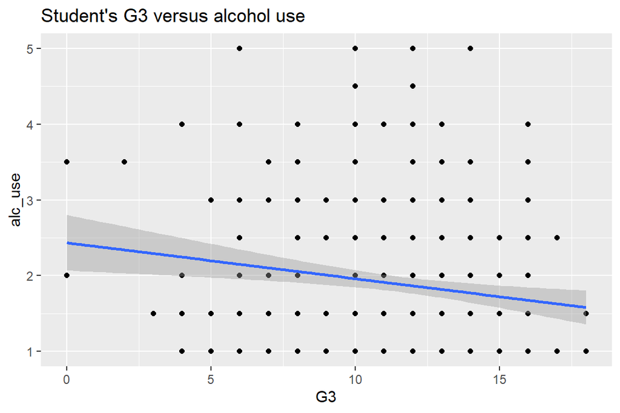

```r
# initialize plot with data and aesthetic mapping
p5 <- ggplot(alc, aes(x = goout, y = alc_use))
p6 <- ggplot(alc, aes(x = failures, y = alc_use))
p7 <- ggplot(alc, aes(x = absences, y = alc_use))
p8 <- ggplot(alc, aes(x = G3, y = alc_use))

# define the visualization type (points) + add a regression line
# + add a main title and draw the plot
p9 <- p5 + geom_point() + geom_smooth(method = "lm") + ggtitle("Student's going out versus alcohol use")
p10 <- p6 + geom_point() + geom_smooth(method = "lm") + ggtitle("Student's failures versus alcohol use")
p11 <- p7 + geom_point() + geom_smooth(method = "lm") + ggtitle("Student's absences versus alcohol use")
p12 <- p8 + geom_point() + geom_smooth(method = "lm") + ggtitle("Student's G3 versus alcohol use")
p9; p10; p11; p12
```

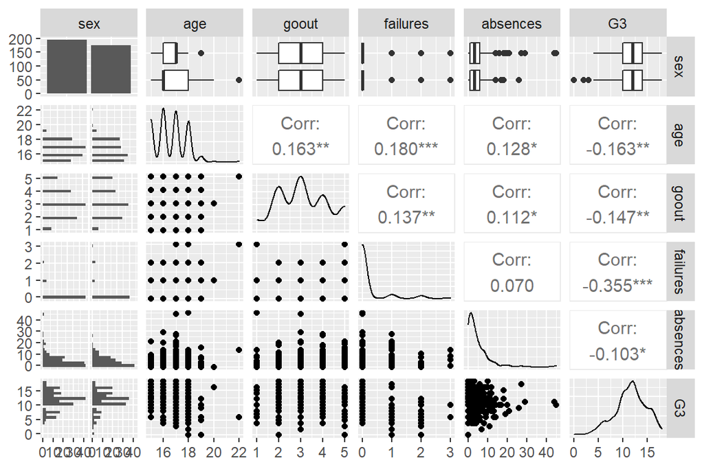

```r
p13 <- ggpairs(alc[, c(3:4, 25, 29, 31, 34)], mapping = aes(), lower = list(combo = wrap("facethist", bins = 20)), progress = FALSE)
p13;
```

```r
# BUILDING A LOGISTIC REGRESSION MODEL

# find the model with glm()
m1 <- glm(high_use ~ age, data = alc, family = "binomial")
m2 <- glm(high_use ~ sex, data = alc, family = "binomial")
m3 <- glm(high_use ~ goout, data = alc, family = "binomial")
m4 <- glm(high_use ~ failures, data = alc, family = "binomial")
m5 <- glm(high_use ~ absences, data = alc, family = "binomial")
m6 <- glm(high_use ~ G3, data = alc, family = "binomial")

m7 <- glm(high_use ~ age + sex, data = alc, family = "binomial")
m8 <- glm(high_use ~ goout + failures + absences + G3, data = alc, family = "binomial")
m9 <- glm(high_use ~ age + sex + goout + failures + absences, data = alc, family = "binomial")
m10 <- glm(high_use ~ sex + goout + failures + absences, data = alc, family = "binomial")

# print out a summary of the model
summary(m1); summary(m2); summary(m3); summary(m4); summary(m5);
```

```
##
## Call:
## glm(formula = high_use ~ age, family = "binomial", data = alc)
##
## Deviance Residuals:
##     Min       1Q   Median       3Q      Max
## -1.0968  -0.8705  -0.8020   1.4319   1.6943
##
## Coefficients:
##             Estimate Std. Error z value Pr(>|z|)
## (Intercept) -4.07538    1.60980  -2.532   0.0114 *
## age          0.19414    0.09628   2.016   0.0438 *
## ---
## Signif. codes:  0 '***' 0.001 '**' 0.01 '*' 0.05 '.' 0.1 ' ' 1
##
## (Dispersion parameter for binomial family taken to be 1)
##
##     Null deviance: 452.04  on 369  degrees of freedom
## Residual deviance: 447.94  on 368  degrees of freedom
## AIC: 451.94
##
## Number of Fisher Scoring iterations: 4
```

```
##
## Call:
## glm(formula = high_use ~ sex, family = "binomial", data = alc)
##
## Deviance Residuals:
##     Min       1Q   Median       3Q      Max
## -1.0108  -1.0108  -0.6871   1.3537   1.7660
##
## Coefficients:
##             Estimate Std. Error z value Pr(>|z|)
## (Intercept)  -1.3234     0.1757  -7.530 5.06e-14 ***
## sexM          0.9179     0.2339   3.925 8.67e-05 ***
## ---
## Signif. codes:  0 '***' 0.001 '**' 0.01 '*' 0.05 '.' 0.1 ' ' 1
##
## (Dispersion parameter for binomial family taken to be 1)
##
##     Null deviance: 452.04  on 369  degrees of freedom
## Residual deviance: 436.13  on 368  degrees of freedom
## AIC: 440.13
##
## Number of Fisher Scoring iterations: 4
```

```
##
## Call:
## glm(formula = high_use ~ goout, family = "binomial", data = alc)
##
## Deviance Residuals:
##     Min       1Q   Median       3Q      Max
## -1.3712  -0.7687  -0.5470   0.9952   2.3037
##
## Coefficients:
##             Estimate Std. Error z value Pr(>|z|)
## (Intercept)  -3.3368     0.4188  -7.968 1.62e-15 ***
## goout         0.7563     0.1165   6.494 8.34e-11 ***
## ---
## Signif. codes:  0 '***' 0.001 '**' 0.01 '*' 0.05 '.' 0.1 ' ' 1
##
## (Dispersion parameter for binomial family taken to be 1)
##
##     Null deviance: 452.04  on 369  degrees of freedom
## Residual deviance: 403.05  on 368  degrees of freedom
## AIC: 407.05
##
## Number of Fisher Scoring iterations: 4
```

```
##
## Call:
## glm(formula = high_use ~ failures, family = "binomial", data = alc)
##
## Deviance Residuals:
##     Min       1Q   Median       3Q      Max
## -1.6367  -0.7943  -0.7943   1.3143   1.6171
##
## Coefficients:
##             Estimate Std. Error z value Pr(>|z|)
## (Intercept)  -0.9920     0.1234  -8.040 8.99e-16 ***
## failures      0.6759     0.1973   3.425 0.000615 ***
## ---
## Signif. codes:  0 '***' 0.001 '**' 0.01 '*' 0.05 '.' 0.1 ' ' 1
##
## (Dispersion parameter for binomial family taken to be 1)
##
##     Null deviance: 452.04  on 369  degrees of freedom
## Residual deviance: 439.75  on 368  degrees of freedom
## AIC: 443.75
##
## Number of Fisher Scoring iterations: 4
```

```
##
## Call:
## glm(formula = high_use ~ absences, family = "binomial", data = alc)
##
## Deviance Residuals:
##     Min       1Q   Median       3Q      Max
## -2.3598  -0.8209  -0.7318   1.2658   1.7419
##
## Coefficients:
##             Estimate Std. Error z value Pr(>|z|)
## (Intercept) -1.26945    0.16094  -7.888 3.08e-15 ***
## absences     0.08867    0.02317   3.827  0.00013 ***
## ---
## Signif. codes:  0 '***' 0.001 '**' 0.01 '*' 0.05 '.' 0.1 ' ' 1
##
## (Dispersion parameter for binomial family taken to be 1)
##
##     Null deviance: 452.04  on 369  degrees of freedom
## Residual deviance: 434.52  on 368  degrees of freedom
## AIC: 438.52
##
## Number of Fisher Scoring iterations: 4
```

```r
summary(m6); summary(m7); summary(m8); summary(m9); summary(m10);
```

```
##
## Call:
## glm(formula = high_use ~ G3, family = "binomial", data = alc)
##
## Deviance Residuals:
##     Min       1Q   Median       3Q      Max
## -1.2365  -0.8551  -0.7651   1.4213   1.7731
##
## Coefficients:
##             Estimate Std. Error z value Pr(>|z|)
## (Intercept)  0.13783    0.40374   0.341   0.7328
## G3          -0.08689    0.03466  -2.507   0.0122 *
## ---
## Signif. codes:  0 '***' 0.001 '**' 0.01 '*' 0.05 '.' 0.1 ' ' 1
##
## (Dispersion parameter for binomial family taken to be 1)
##
##     Null deviance: 452.04  on 369  degrees of freedom
## Residual deviance: 445.68  on 368  degrees of freedom
## AIC: 449.68
##
## Number of Fisher Scoring iterations: 4
```

```
##
## Call:
## glm(formula = high_use ~ age + sex, family = "binomial", data = alc)
##
## Deviance Residuals:
##     Min       1Q   Median       3Q      Max
## -1.3034  -0.8870  -0.7086   1.2275   1.9163
##
## Coefficients:
##             Estimate Std. Error z value Pr(>|z|)
## (Intercept) -4.72614    1.65095  -2.863   0.0042 **
## age          0.20425    0.09812   2.082   0.0374 *
## sexM         0.93259    0.23552   3.960 7.51e-05 ***
## ---
## Signif. codes:  0 '***' 0.001 '**' 0.01 '*' 0.05 '.' 0.1 ' ' 1
##
## (Dispersion parameter for binomial family taken to be 1)
##
##     Null deviance: 452.04  on 369  degrees of freedom
## Residual deviance: 431.73  on 367  degrees of freedom
## AIC: 437.73
##
## Number of Fisher Scoring iterations: 4
```

```
##
## Call:
## glm(formula = high_use ~ goout + failures + absences + G3, family = "binomial",
##     data = alc)
##
## Deviance Residuals:
##     Min       1Q   Median       3Q      Max
## -2.0077  -0.7367  -0.5427   0.9191   2.3664
##
## Coefficients:
##             Estimate Std. Error z value Pr(>|z|)
## (Intercept) -3.42137    0.69467  -4.925 8.43e-07 ***
## goout        0.69791    0.11881   5.874 4.25e-09 ***
## failures     0.52078    0.23720   2.195 0.028128 *
## absences     0.07373    0.02233   3.303 0.000958 ***
## G3          -0.01612    0.04171  -0.386 0.699253
## ---
## Signif. codes:  0 '***' 0.001 '**' 0.01 '*' 0.05 '.' 0.1 ' ' 1
##
## (Dispersion parameter for binomial family taken to be 1)
##
##     Null deviance: 452.04  on 369  degrees of freedom
## Residual deviance: 383.91  on 365  degrees of freedom
## AIC: 393.91
##
## Number of Fisher Scoring iterations: 4
```

```
##
## Call:
## glm(formula = high_use ~ age + sex + goout + failures + absences,
##     family = "binomial", data = alc)
##
## Deviance Residuals:
##     Min       1Q   Median       3Q      Max
## -2.1461  -0.7853  -0.5274   0.7258   2.3609
##
## Coefficients:
##             Estimate Std. Error z value Pr(>|z|)
## (Intercept) -4.72724    1.89765  -2.491 0.012735 *
## age          0.03623    0.11375   0.318 0.750115
## sexM         0.98157    0.26166   3.751 0.000176 ***
## goout        0.69397    0.12157   5.708 1.14e-08 ***
## failures     0.47932    0.23331   2.054 0.039930 *
## absences     0.08171    0.02276   3.590 0.000331 ***
## ---
## Signif. codes:  0 '***' 0.001 '**' 0.01 '*' 0.05 '.' 0.1 ' ' 1
##
## (Dispersion parameter for binomial family taken to be 1)
##
##     Null deviance: 452.04  on 369  degrees of freedom
## Residual deviance: 369.40  on 364  degrees of freedom
## AIC: 381.4
##
## Number of Fisher Scoring iterations: 4
```

```
##
## Call:
## glm(formula = high_use ~ sex + goout + failures + absences, family = "binomial",
##     data = alc)
##
## Deviance Residuals:
##     Min       1Q   Median       3Q      Max
## -2.1521  -0.7929  -0.5317   0.7412   2.3706
##
## Coefficients:
##             Estimate Std. Error z value Pr(>|z|)
## (Intercept) -4.14389    0.47881  -8.654  < 2e-16 ***
## sexM         0.97989    0.26156   3.746 0.000179 ***
## goout        0.69801    0.12093   5.772 7.83e-09 ***
## failures     0.48932    0.23073   2.121 0.033938 *
## absences     0.08246    0.02266   3.639 0.000274 ***
## ---
## Signif. codes:  0 '***' 0.001 '**' 0.01 '*' 0.05 '.' 0.1 ' ' 1
##
## (Dispersion parameter for binomial family taken to be 1)
##
##     Null deviance: 452.04  on 369  degrees of freedom
## Residual deviance: 369.50  on 365  degrees of freedom
## AIC: 379.5
##
## Number of Fisher Scoring iterations: 4
```

```r
# print out the coefficients of the model
coef(m1); coef(m2); coef(m3); coef(m4); coef(m5);
```

```
## (Intercept)         age
##  -4.0753783   0.1941355
```

```
## (Intercept)        sexM
##  -1.3233805   0.9179154
```

```
## (Intercept)       goout
##  -3.3368302   0.7563474
```

```
## (Intercept)    failures
##  -0.9920231   0.6758788
```

```
## (Intercept)    absences
## -1.26944532  0.08866504
```

```r
coef(m6); coef(m7); coef(m8); coef(m9); coef(m10);
```

```
## (Intercept)          G3
##   0.1378294  -0.0868889
```

```
## (Intercept)         age        sexM
##  -4.7261439   0.2042451   0.9325859
```

```
## (Intercept)       goout    failures    absences          G3
## -3.42137467  0.69790726  0.52077970  0.07373480 -0.01611567
```

```
## (Intercept)         age        sexM       goout    failures    absences
## -4.72723868  0.03622756  0.98157242  0.69396783  0.47932468  0.08171370
```

```
## (Intercept)        sexM       goout    failures    absences
## -4.14389330  0.97988506  0.69801208  0.48932427  0.08245946
```

```r
# comparing models
m82 <- glm(high_use ~ goout + failures + absences, data = alc, family = "binomial")
anova(m8, m82, test="LRT")
```

```
## Analysis of Deviance Table
##
## Model 1: high_use ~ goout + failures + absences + G3
## Model 2: high_use ~ goout + failures + absences
##   Resid. Df Resid. Dev Df Deviance Pr(>Chi)
## 1       365     383.91
## 2       366     384.06 -1 -0.14891   0.6996
```

```r
anova(m9, m10, test="LRT")
```

```
## Analysis of Deviance Table
##
## Model 1: high_use ~ age + sex + goout + failures + absences
## Model 2: high_use ~ sex + goout + failures + absences
##   Resid. Df Resid. Dev Df Deviance Pr(>Chi)
## 1       364      369.4
## 2       365      369.5 -1 -0.10135   0.7502
```

```r
# compute odds ratios (OR) and confidence intervals (CI) for the final model
OR10 <- coef(m10) %>% exp %>% round(digits = 2)
CI10 <- confint(m10) %>% exp %>% round(digits = 2)
# print out the odds ratios with their confidence intervals
cbind(OR10, CI10)
```

```
##             OR10 2.5 % 97.5 %
## (Intercept) 0.02  0.01   0.04
## sexM        2.66  1.61   4.49
## goout       2.01  1.59   2.56
## failures    1.63  1.04   2.59
## absences    1.09  1.04   1.14
```

In univariate logistic regression models, all selected explanatory variables as well as age and sex as demographic factors are statistically significantly associated with high alcohol use. In a multiple regression model, however, final grade and age are not any more significantly associated with high alcohol consumption. Likelihood ratio tests being insignificant also favor leaving them out of the final model. The point estimates of included explanatory variables in the final model are nearly the same as in the respective univariate models.

In the final model, one unit increase in going out increased the odds of using alcohol at high level by 101% (59%-156%), in failures by 63% (4%-159%) and in absences by 9% (4%-14%). Male sex increased the odds (95% CI) by 166% (61%-349%).

```r
# PREDICTIVE ABILITY OF THE FINAL MODEL

## access dplyr and ggplot2
library(dplyr); library(ggplot2)

# fit the model
m10 <- glm(high_use ~ sex + goout + failures + absences, data = alc, family = "binomial")

# predict() the probability of high_use
probabilities <- predict(m10, type = "response")

# add the predicted probabilities to 'alc'
alc <- mutate(alc, probability = probabilities)

# use the probabilities to make a prediction of high_use
alc <- mutate(alc, prediction = probability > 0.5)

# tabulate the target variable versus the predictions
table(high_use = alc$high_use, prediction = alc$prediction) %>% addmargins %>% round(digits = 2)
```

```
##         prediction
## high_use FALSE TRUE Sum
##    FALSE   243   16 259
##    TRUE     61   50 111
##    Sum     304   66 370
```

```r
table(high_use = alc$high_use, prediction = alc$prediction) %>% prop.table %>% addmargins %>% round(digits = 2)
```

```
##         prediction
## high_use FALSE TRUE  Sum
##    FALSE  0.66 0.04 0.70
##    TRUE   0.16 0.14 0.30
##    Sum    0.82 0.18 1.00
```

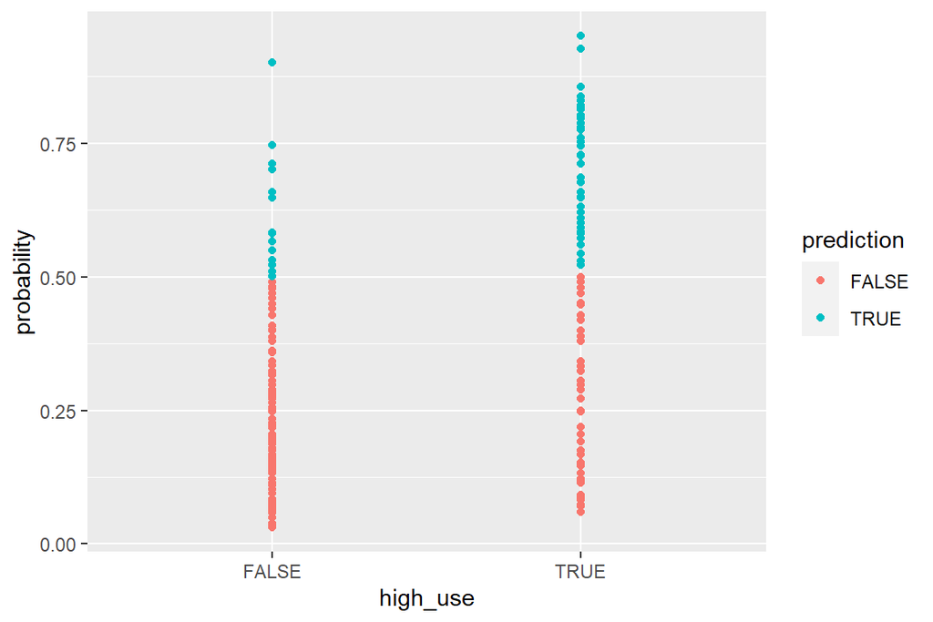

```r
# initialize a plot of 'high_use' versus 'probability' in 'alc'
g <- ggplot(alc, aes(x = high_use, y = probability, col = prediction))

# define the geom as points and draw the plot
g + geom_point()
```

```r
# define a loss function (mean prediction error)
loss_func <- function(class, prob) {
  n_wrong <- abs(class - prob) > 0.5
  mean(n_wrong)
}

# call loss_func to compute the average number of wrong predictions in the (training) data
loss_func(class = alc$high_use, prob = 0) %>% round(digits = 2)
```

```
## [1] 0.3
```

```r
loss_func(class = alc$high_use, prob = 1) %>% round(digits = 2)
```

```
## [1] 0.7
```

```r
loss_func(class = alc$high_use, prob = alc$probability) %>% round(digits = 2)
```

```
## [1] 0.21
```

The model does increase the predictive performance compared to random guessing: 21% are inaccurately classified by the model, whereas 30% are inaccurately classified by randomly guessing that probability is 0 for all and 70 % by a randomly guessing that probability is 1 for all.

```r
# BONUS SECTION: ON CROSS-VALIDATION

# K-fold cross-validation
library(boot)
cv <- cv.glm(data = alc, cost = loss_func, glmfit = m10, K = nrow(alc) / 10)

# average number of wrong predictions in the cross validation
cv$delta[1]
```

```
## [1] 0.2108108
```

The final model does have a slightly better test set performance, error being 0.21 compared with the respective error produced by the model in the Exercise Set (0.26).

```r
# SUPER-BONUS SECTION: ON CROSS-VALIDATION

# I'm sure there is a much more elegant way of writing this R code...

# different models and their summaries
m21 <- glm(high_use ~ age + sex + health + address + famsize + Pstatus + Fedu + Mjob + guardian + school + reason + schoolsup + famsup + paid + activities + nursery + higher + internet + romantic + famrel + studytime + traveltime + freetime + goout + failures + absences + G3, data = alc, family = "binomial")
summary(m21)
```

```
##
## Call:
## glm(formula = high_use ~ age + sex + health + address + famsize +
##     Pstatus + Fedu + Mjob + guardian + school + reason + schoolsup +
##     famsup + paid + activities + nursery + higher + internet +
##     romantic + famrel + studytime + traveltime + freetime + goout +
##     failures + absences + G3, family = "binomial", data = alc)
##
## Deviance Residuals:
##     Min       1Q   Median       3Q      Max
## -1.7733  -0.6942  -0.3703   0.5275   2.8698
##
## Coefficients:
##                  Estimate Std. Error z value Pr(>|z|)
## (Intercept)      -3.06934    2.95252  -1.040 0.298541
## age               0.05401    0.14774   0.366 0.714696
## sexM              0.86707    0.33018   2.626 0.008639 **
## health            0.19978    0.11237   1.778 0.075433 .
## addressU         -0.85388    0.41398  -2.063 0.039149 *
## famsizeLE3        0.50174    0.32064   1.565 0.117621
## PstatusT         -0.21412    0.51220  -0.418 0.675910
## Fedu              0.04477    0.15749   0.284 0.776218
## Mjobhealth       -0.86921    0.66777  -1.302 0.193033
## Mjobother        -0.76813    0.46827  -1.640 0.100929
## Mjobservices     -0.65342    0.51502  -1.269 0.204540
## Mjobteacher      -0.36452    0.57503  -0.634 0.526139
## guardianmother   -0.81573    0.36120  -2.258 0.023921 *
## guardianother    -0.02361    0.77809  -0.030 0.975790
## schoolMS         -0.41859    0.55098  -0.760 0.447418
## reasonhome        0.43518    0.38491   1.131 0.258223
## reasonother       1.33386    0.52127   2.559 0.010501 *
## reasonreputation -0.05167    0.40177  -0.129 0.897677
## schoolsupyes      0.07500    0.45298   0.166 0.868493
## famsupyes        -0.15239    0.32301  -0.472 0.637080
## paidyes           0.64657    0.31745   2.037 0.041673 *
## activitiesyes    -0.54344    0.30862  -1.761 0.078264 .
## nurseryyes       -0.46789    0.36303  -1.289 0.197453
## higheryes        -0.17828    0.71758  -0.248 0.803787
## internetyes       0.21525    0.44485   0.484 0.628467
## romanticyes      -0.53828    0.32531  -1.655 0.097993 .
## famrel           -0.52687    0.16561  -3.181 0.001465 **
## studytime        -0.28025    0.20271  -1.382 0.166824
## traveltime        0.25226    0.22899   1.102 0.270621
## freetime          0.23073    0.16392   1.408 0.159248
## goout             0.87900    0.15327   5.735 9.75e-09 ***
## failures          0.29553    0.27415   1.078 0.281042
## absences          0.09199    0.02614   3.519 0.000433 ***
## G3                0.02725    0.05191   0.525 0.599637
## ---
## Signif. codes:  0 '***' 0.001 '**' 0.01 '*' 0.05 '.' 0.1 ' ' 1
##
## (Dispersion parameter for binomial family taken to be 1)
##
##     Null deviance: 452.04  on 369  degrees of freedom
## Residual deviance: 318.90  on 336  degrees of freedom
## AIC: 386.9
##
## Number of Fisher Scoring iterations: 5
```

```r
m22 <- glm(high_use ~ age + sex + health + address + famsize + Pstatus + Fedu + Mjob + guardian + school + reason + famsup + paid + activities + nursery + higher + internet + romantic + famrel + studytime + traveltime + freetime + goout + failures + absences + G3, data = alc, family = "binomial")
summary(m22)
```

```
##
## Call:
## glm(formula = high_use ~ age + sex + health + address + famsize +
##     Pstatus + Fedu + Mjob + guardian + school + reason + famsup +
##     paid + activities + nursery + higher + internet + romantic +
##     famrel + studytime + traveltime + freetime + goout + failures +
##     absences + G3, family = "binomial", data = alc)
##
## Deviance Residuals:
##     Min       1Q   Median       3Q      Max
## -1.7609  -0.6940  -0.3720   0.5267   2.8647
##
## Coefficients:
##                  Estimate Std. Error z value Pr(>|z|)
## (Intercept)      -2.96925    2.89116  -1.027 0.304415
## age               0.04918    0.14482   0.340 0.734150
## sexM              0.85938    0.32682   2.630 0.008551 **
## health            0.19904    0.11228   1.773 0.076282 .
## addressU         -0.84988    0.41350  -2.055 0.039849 *
## famsizeLE3        0.49997    0.32044   1.560 0.118693
## PstatusT         -0.21693    0.51219  -0.424 0.671902
## Fedu              0.04554    0.15741   0.289 0.772346
## Mjobhealth       -0.87549    0.66660  -1.313 0.189056
## Mjobother        -0.77016    0.46819  -1.645 0.099975 .
## Mjobservices     -0.65192    0.51482  -1.266 0.205401
## Mjobteacher      -0.36879    0.57448  -0.642 0.520900
## guardianmother   -0.81692    0.36120  -2.262 0.023718 *
## guardianother    -0.02329    0.77775  -0.030 0.976110
## schoolMS         -0.42351    0.55004  -0.770 0.441325
## reasonhome        0.43646    0.38496   1.134 0.256889
## reasonother       1.33457    0.52098   2.562 0.010417 *
## reasonreputation -0.05037    0.40179  -0.125 0.900245
## famsupyes        -0.15014    0.32279  -0.465 0.641833
## paidyes           0.64340    0.31691   2.030 0.042334 *
## activitiesyes    -0.53930    0.30764  -1.753 0.079599 .
## nurseryyes       -0.46621    0.36269  -1.285 0.198650
## higheryes        -0.17380    0.71753  -0.242 0.808610
## internetyes       0.21588    0.44490   0.485 0.627516
## romanticyes      -0.53981    0.32514  -1.660 0.096873 .
## famrel           -0.52685    0.16560  -3.181 0.001465 **
## studytime        -0.27968    0.20274  -1.380 0.167738
## traveltime        0.25567    0.22830   1.120 0.262772
## freetime          0.23063    0.16394   1.407 0.159502
## goout             0.87846    0.15325   5.732  9.9e-09 ***
## failures          0.29549    0.27438   1.077 0.281504
## absences          0.09192    0.02612   3.519 0.000433 ***
## G3                0.02598    0.05130   0.506 0.612585
## ---
## Signif. codes:  0 '***' 0.001 '**' 0.01 '*' 0.05 '.' 0.1 ' ' 1
##
## (Dispersion parameter for binomial family taken to be 1)
##
##     Null deviance: 452.04  on 369  degrees of freedom
## Residual deviance: 318.93  on 337  degrees of freedom
## AIC: 384.93
##
## Number of Fisher Scoring iterations: 5
```

```r
m23 <- glm(high_use ~ age + sex + health + address + famsize + Pstatus + Fedu + Mjob + guardian + school + reason + famsup + paid + activities + nursery + internet + romantic + famrel + studytime + traveltime + freetime + goout + failures + absences + G3, data = alc, family = "binomial")
summary(m23)
```

```
##
## Call:
## glm(formula = high_use ~ age + sex + health + address + famsize +
##     Pstatus + Fedu + Mjob + guardian + school + reason + famsup +
##     paid + activities + nursery + internet + romantic + famrel +
##     studytime + traveltime + freetime + goout + failures + absences +
##     G3, family = "binomial", data = alc)
##
## Deviance Residuals:
##     Min       1Q   Median       3Q      Max
## -1.7885  -0.6919  -0.3695   0.5206   2.8581
##
## Coefficients:
##                  Estimate Std. Error z value Pr(>|z|)
## (Intercept)      -3.19543    2.73368  -1.169 0.242440
## age               0.05587    0.14190   0.394 0.693793
## sexM              0.86745    0.32512   2.668 0.007629 **
## health            0.19870    0.11227   1.770 0.076750 .
## addressU         -0.85349    0.41317  -2.066 0.038858 *
## famsizeLE3        0.49873    0.32026   1.557 0.119410
## PstatusT         -0.21809    0.51176  -0.426 0.669994
## Fedu              0.04169    0.15666   0.266 0.790163
## Mjobhealth       -0.88016    0.66551  -1.323 0.185988
## Mjobother        -0.77519    0.46717  -1.659 0.097050 .
## Mjobservices     -0.65521    0.51392  -1.275 0.202341
## Mjobteacher      -0.37101    0.57428  -0.646 0.518248
## guardianmother   -0.81986    0.36078  -2.272 0.023060 *
## guardianother    -0.03054    0.77805  -0.039 0.968686
## schoolMS         -0.43916    0.54672  -0.803 0.421826
## reasonhome        0.43014    0.38412   1.120 0.262790
## reasonother       1.33275    0.52008   2.563 0.010389 *
## reasonreputation -0.05181    0.40164  -0.129 0.897366
## famsupyes        -0.15501    0.32206  -0.481 0.630290
## paidyes           0.63438    0.31470   2.016 0.043817 *
## activitiesyes    -0.54909    0.30503  -1.800 0.071840 .
## nurseryyes       -0.46197    0.36200  -1.276 0.201902
## internetyes       0.22716    0.44252   0.513 0.607727
## romanticyes      -0.52965    0.32216  -1.644 0.100163
## famrel           -0.52666    0.16560  -3.180 0.001471 **
## studytime        -0.28176    0.20239  -1.392 0.163879
## traveltime        0.25472    0.22814   1.117 0.264205
## freetime          0.22989    0.16397   1.402 0.160909
## goout             0.87855    0.15327   5.732 9.93e-09 ***
## failures          0.30386    0.27304   1.113 0.265750
## absences          0.09209    0.02602   3.540 0.000401 ***
## G3                0.02346    0.05022   0.467 0.640372
## ---
## Signif. codes:  0 '***' 0.001 '**' 0.01 '*' 0.05 '.' 0.1 ' ' 1
##
## (Dispersion parameter for binomial family taken to be 1)
##
##     Null deviance: 452.04  on 369  degrees of freedom
## Residual deviance: 318.98  on 338  degrees of freedom
## AIC: 382.98
##
## Number of Fisher Scoring iterations: 5
```

```r
m24 <- glm(high_use ~ age + sex + health + address + famsize + Pstatus + Mjob + guardian + school + reason + famsup + paid + activities + nursery + internet + romantic + famrel + studytime + traveltime + freetime + goout + failures + absences + G3, data = alc, family = "binomial")
summary(m24)
```

```
##
## Call:
## glm(formula = high_use ~ age + sex + health + address + famsize +
##     Pstatus + Mjob + guardian + school + reason + famsup + paid +
##     activities + nursery + internet + romantic + famrel + studytime +
##     traveltime + freetime + goout + failures + absences + G3,
##     family = "binomial", data = alc)
##
## Deviance Residuals:
##     Min       1Q   Median       3Q      Max
## -1.8024  -0.6867  -0.3726   0.5270   2.8586
##
## Coefficients:
##                  Estimate Std. Error z value Pr(>|z|)
## (Intercept)      -3.05049    2.67834  -1.139 0.254725
## age               0.05400    0.14173   0.381 0.703172
## sexM              0.86914    0.32518   2.673 0.007522 **
## health            0.19961    0.11211   1.781 0.074992 .
## addressU         -0.85786    0.41243  -2.080 0.037526 *
## famsizeLE3        0.48881    0.31803   1.537 0.124296
## PstatusT         -0.23584    0.50787  -0.464 0.642377
## Mjobhealth       -0.86508    0.66285  -1.305 0.191865
## Mjobother        -0.78793    0.46436  -1.697 0.089737 .
## Mjobservices     -0.65306    0.51381  -1.271 0.203720
## Mjobteacher      -0.33772    0.56006  -0.603 0.546508
## guardianmother   -0.84113    0.35206  -2.389 0.016887 *
## guardianother    -0.03532    0.77788  -0.045 0.963782
## schoolMS         -0.43365    0.54688  -0.793 0.427804
## reasonhome        0.43122    0.38402   1.123 0.261480
## reasonother       1.33397    0.52063   2.562 0.010400 *
## reasonreputation -0.04724    0.40116  -0.118 0.906266
## famsupyes        -0.14646    0.32032  -0.457 0.647509
## paidyes           0.63330    0.31460   2.013 0.044111 *
## activitiesyes    -0.54591    0.30486  -1.791 0.073341 .
## nurseryyes       -0.44785    0.35820  -1.250 0.211199
## internetyes       0.23102    0.44189   0.523 0.601110
## romanticyes      -0.52520    0.32146  -1.634 0.102303
## famrel           -0.52726    0.16571  -3.182 0.001463 **
## studytime        -0.28577    0.20165  -1.417 0.156434
## traveltime        0.24871    0.22696   1.096 0.273141
## freetime          0.22620    0.16335   1.385 0.166121
## goout             0.88397    0.15201   5.815 6.06e-09 ***
## failures          0.28968    0.26763   1.082 0.279066
## absences          0.09278    0.02592   3.579 0.000345 ***
## G3                0.02455    0.05001   0.491 0.623489
## ---
## Signif. codes:  0 '***' 0.001 '**' 0.01 '*' 0.05 '.' 0.1 ' ' 1
##
## (Dispersion parameter for binomial family taken to be 1)
##
##     Null deviance: 452.04  on 369  degrees of freedom
## Residual deviance: 319.05  on 339  degrees of freedom
## AIC: 381.05
##
## Number of Fisher Scoring iterations: 5
```

```r
m25 <- glm(high_use ~ sex + health + address + famsize + Pstatus + Mjob + guardian + school + reason + famsup + paid + activities + nursery + internet + romantic + famrel + studytime + traveltime + freetime + goout + failures + absences + G3, data = alc, family = "binomial")
summary(m25)
```

```
##
## Call:
## glm(formula = high_use ~ sex + health + address + famsize + Pstatus +
##     Mjob + guardian + school + reason + famsup + paid + activities +
##     nursery + internet + romantic + famrel + studytime + traveltime +
##     freetime + goout + failures + absences + G3, family = "binomial",
##     data = alc)
##
## Deviance Residuals:
##     Min       1Q   Median       3Q      Max
## -1.8115  -0.6780  -0.3741   0.5351   2.8662
##
## Coefficients:
##                  Estimate Std. Error z value Pr(>|z|)
## (Intercept)      -2.18345    1.40586  -1.553 0.120398
## sexM              0.87542    0.32423   2.700 0.006935 **
## health            0.19812    0.11194   1.770 0.076744 .
## addressU         -0.87032    0.41091  -2.118 0.034173 *
## famsizeLE3        0.48549    0.31783   1.528 0.126636
## PstatusT         -0.23136    0.50751  -0.456 0.648477
## Mjobhealth       -0.86599    0.66254  -1.307 0.191187
## Mjobother        -0.78347    0.46470  -1.686 0.091799 .
## Mjobservices     -0.65478    0.51433  -1.273 0.202993
## Mjobteacher      -0.33410    0.55988  -0.597 0.550689
## guardianmother   -0.83727    0.35200  -2.379 0.017378 *
## guardianother     0.03273    0.75903   0.043 0.965609
## schoolMS         -0.36884    0.52019  -0.709 0.478288
## reasonhome        0.42938    0.38416   1.118 0.263691
## reasonother       1.31806    0.51857   2.542 0.011030 *
## reasonreputation -0.04819    0.40091  -0.120 0.904328
## famsupyes        -0.15410    0.31946  -0.482 0.629540
## paidyes           0.63749    0.31432   2.028 0.042544 *
## activitiesyes    -0.54843    0.30457  -1.801 0.071751 .
## nurseryyes       -0.43975    0.35738  -1.231 0.218509
## internetyes       0.22314    0.44134   0.506 0.613142
## romanticyes      -0.50541    0.31711  -1.594 0.110986
## famrel           -0.52404    0.16539  -3.169 0.001532 **
## studytime        -0.28015    0.20040  -1.398 0.162138
## traveltime        0.24680    0.22724   1.086 0.277444
## freetime          0.22240    0.16299   1.365 0.172397
## goout             0.88971    0.15127   5.881 4.07e-09 ***
## failures          0.30230    0.26479   1.142 0.253582
## absences          0.09363    0.02576   3.635 0.000278 ***
## G3                0.02386    0.05003   0.477 0.633404
## ---
## Signif. codes:  0 '***' 0.001 '**' 0.01 '*' 0.05 '.' 0.1 ' ' 1
##
## (Dispersion parameter for binomial family taken to be 1)
##
##     Null deviance: 452.04  on 369  degrees of freedom
## Residual deviance: 319.20  on 340  degrees of freedom
## AIC: 379.2
##
## Number of Fisher Scoring iterations: 5
```

```r
m26 <- glm(high_use ~ sex + health + address + famsize + Mjob + guardian + school + reason + famsup + paid + activities + nursery + internet + romantic + famrel + studytime + traveltime + freetime + goout + failures + absences + G3, data = alc, family = "binomial")
summary(m26)
```

```
##
## Call:
## glm(formula = high_use ~ sex + health + address + famsize + Mjob +
##     guardian + school + reason + famsup + paid + activities +
##     nursery + internet + romantic + famrel + studytime + traveltime +
##     freetime + goout + failures + absences + G3, family = "binomial",
##     data = alc)
##
## Deviance Residuals:
##     Min       1Q   Median       3Q      Max
## -1.8257  -0.6871  -0.3759   0.5287   2.8577
##
## Coefficients:
##                  Estimate Std. Error z value Pr(>|z|)
## (Intercept)      -2.39445    1.32839  -1.803 0.071465 .
## sexM              0.87214    0.32419   2.690 0.007141 **
## health            0.19659    0.11203   1.755 0.079284 .
## addressU         -0.87215    0.41028  -2.126 0.033526 *
## famsizeLE3        0.49404    0.31668   1.560 0.118747
## Mjobhealth       -0.85441    0.66232  -1.290 0.197039
## Mjobother        -0.75819    0.46117  -1.644 0.100168
## Mjobservices     -0.63041    0.51137  -1.233 0.217651
## Mjobteacher      -0.31297    0.55700  -0.562 0.574195
## guardianmother   -0.82015    0.34963  -2.346 0.018987 *
## guardianother     0.07088    0.76004   0.093 0.925699
## schoolMS         -0.37703    0.51952  -0.726 0.468011
## reasonhome        0.42329    0.38397   1.102 0.270289
## reasonother       1.31565    0.51775   2.541 0.011051 *
## reasonreputation -0.04565    0.40123  -0.114 0.909410
## famsupyes        -0.15297    0.31920  -0.479 0.631787
## paidyes           0.62587    0.31306   1.999 0.045585 *
## activitiesyes    -0.55798    0.30363  -1.838 0.066104 .
## nurseryyes       -0.42608    0.35608  -1.197 0.231472
## internetyes       0.20904    0.44029   0.475 0.634943
## romanticyes      -0.50246    0.31704  -1.585 0.113007
## famrel           -0.52594    0.16579  -3.172 0.001512 **
## studytime        -0.28026    0.20035  -1.399 0.161869
## traveltime        0.24293    0.22631   1.073 0.283073
## freetime          0.21494    0.16181   1.328 0.184067
## goout             0.88814    0.15097   5.883 4.04e-09 ***
## failures          0.30053    0.26510   1.134 0.256940
## absences          0.09458    0.02555   3.702 0.000214 ***
## G3                0.02611    0.04981   0.524 0.600062
## ---
## Signif. codes:  0 '***' 0.001 '**' 0.01 '*' 0.05 '.' 0.1 ' ' 1
##
## (Dispersion parameter for binomial family taken to be 1)
##
##     Null deviance: 452.04  on 369  degrees of freedom
## Residual deviance: 319.40  on 341  degrees of freedom
## AIC: 377.4
##
## Number of Fisher Scoring iterations: 5
```

```r
m27 <- glm(high_use ~ sex + health + address + famsize + Mjob + guardian + school + reason + famsup + paid + activities + nursery + romantic + famrel + studytime + traveltime + freetime + goout + failures + absences + G3, data = alc, family = "binomial")
summary(m27)
```

```
##
## Call:
## glm(formula = high_use ~ sex + health + address + famsize + Mjob +
##     guardian + school + reason + famsup + paid + activities +
##     nursery + romantic + famrel + studytime + traveltime + freetime +
##     goout + failures + absences + G3, family = "binomial", data = alc)
##
## Deviance Residuals:
##     Min       1Q   Median       3Q      Max
## -1.8328  -0.6796  -0.3747   0.5404   2.8683
##
## Coefficients:
##                  Estimate Std. Error z value Pr(>|z|)
## (Intercept)      -2.32240    1.31885  -1.761 0.078251 .
## sexM              0.87340    0.32425   2.694 0.007068 **
## health            0.19373    0.11162   1.736 0.082649 .
## addressU         -0.83448    0.40234  -2.074 0.038073 *
## famsizeLE3        0.49752    0.31629   1.573 0.115724
## Mjobhealth       -0.79381    0.65218  -1.217 0.223542
## Mjobother        -0.71259    0.45084  -1.581 0.113970
## Mjobservices     -0.57330    0.49752  -1.152 0.249191
## Mjobteacher      -0.25368    0.54375  -0.467 0.640826
## guardianmother   -0.82837    0.34921  -2.372 0.017686 *
## guardianother     0.05555    0.75518   0.074 0.941360
## schoolMS         -0.37018    0.51814  -0.714 0.474950
## reasonhome        0.41920    0.38397   1.092 0.274942
## reasonother       1.31310    0.51752   2.537 0.011172 *
## reasonreputation -0.04511    0.40044  -0.113 0.910317
## famsupyes        -0.14499    0.31820  -0.456 0.648633
## paidyes           0.63651    0.31213   2.039 0.041427 *
## activitiesyes    -0.54865    0.30311  -1.810 0.070282 .
## nurseryyes       -0.44357    0.35358  -1.255 0.209647
## romanticyes      -0.49066    0.31597  -1.553 0.120454
## famrel           -0.52478    0.16579  -3.165 0.001549 **
## studytime        -0.27793    0.20027  -1.388 0.165190
## traveltime        0.24304    0.22637   1.074 0.282979
## freetime          0.21735    0.16147   1.346 0.178275
## goout             0.89168    0.15095   5.907 3.48e-09 ***
## failures          0.29404    0.26526   1.109 0.267637
## absences          0.09631    0.02527   3.811 0.000139 ***
## G3                0.02666    0.04981   0.535 0.592451
## ---
## Signif. codes:  0 '***' 0.001 '**' 0.01 '*' 0.05 '.' 0.1 ' ' 1
##
## (Dispersion parameter for binomial family taken to be 1)
##
##     Null deviance: 452.04  on 369  degrees of freedom
## Residual deviance: 319.63  on 342  degrees of freedom
## AIC: 375.63
##
## Number of Fisher Scoring iterations: 5
```

```r
m28 <- glm(high_use ~ sex + health + address + famsize + Mjob + guardian + school + reason + paid + activities + nursery + romantic + famrel + studytime + traveltime + freetime + goout + failures + absences + G3, data = alc, family = "binomial")
summary(m28)
```

```
##
## Call:
## glm(formula = high_use ~ sex + health + address + famsize + Mjob +
##     guardian + school + reason + paid + activities + nursery +
##     romantic + famrel + studytime + traveltime + freetime + goout +
##     failures + absences + G3, family = "binomial", data = alc)
##
## Deviance Residuals:
##     Min       1Q   Median       3Q      Max
## -1.8383  -0.6862  -0.3765   0.5306   2.8548
##
## Coefficients:
##                  Estimate Std. Error z value Pr(>|z|)
## (Intercept)      -2.38141    1.31082  -1.817 0.069258 .
## sexM              0.89197    0.32200   2.770 0.005605 **
## health            0.18934    0.11099   1.706 0.088019 .
## addressU         -0.82360    0.40107  -2.054 0.040024 *
## famsizeLE3        0.50629    0.31542   1.605 0.108462
## Mjobhealth       -0.83338    0.64562  -1.291 0.196763
## Mjobother        -0.70548    0.45022  -1.567 0.117122
## Mjobservices     -0.58517    0.49658  -1.178 0.238640
## Mjobteacher      -0.27326    0.54111  -0.505 0.613565
## guardianmother   -0.82408    0.34927  -2.359 0.018302 *
## guardianother     0.03067    0.75544   0.041 0.967611
## schoolMS         -0.33536    0.51293  -0.654 0.513234
## reasonhome        0.41271    0.38353   1.076 0.281888
## reasonother       1.32527    0.51650   2.566 0.010292 *
## reasonreputation -0.04696    0.39985  -0.117 0.906507
## paidyes           0.60780    0.30520   1.991 0.046429 *
## activitiesyes    -0.54458    0.30288  -1.798 0.072176 .
## nurseryyes       -0.44167    0.35364  -1.249 0.211699
## romanticyes      -0.49720    0.31594  -1.574 0.115551
## famrel           -0.52100    0.16548  -3.148 0.001642 **
## studytime        -0.28997    0.19876  -1.459 0.144587
## traveltime        0.24073    0.22604   1.065 0.286887
## freetime          0.21119    0.16069   1.314 0.188762
## goout             0.89196    0.15073   5.918 3.27e-09 ***
## failures          0.29978    0.26516   1.131 0.258244
## absences          0.09569    0.02512   3.810 0.000139 ***
## G3                0.02776    0.04978   0.558 0.577025
## ---
## Signif. codes:  0 '***' 0.001 '**' 0.01 '*' 0.05 '.' 0.1 ' ' 1
##
## (Dispersion parameter for binomial family taken to be 1)
##
##     Null deviance: 452.04  on 369  degrees of freedom
## Residual deviance: 319.84  on 343  degrees of freedom
## AIC: 373.84
##
## Number of Fisher Scoring iterations: 5
```

```r
m29 <- glm(high_use ~ sex + health + address + famsize + Mjob + guardian + school + reason + paid + activities + nursery + romantic + famrel + studytime + traveltime + freetime + goout + failures + absences, data = alc, family = "binomial")
summary(m29)
```

```
##
## Call:
## glm(formula = high_use ~ sex + health + address + famsize + Mjob +
##     guardian + school + reason + paid + activities + nursery +
##     romantic + famrel + studytime + traveltime + freetime + goout +
##     failures + absences, family = "binomial", data = alc)
##
## Deviance Residuals:
##     Min       1Q   Median       3Q      Max
## -1.8834  -0.6840  -0.3776   0.5414   2.8104
##
## Coefficients:
##                  Estimate Std. Error z value Pr(>|z|)
## (Intercept)      -2.05408    1.16884  -1.757 0.078855 .
## sexM              0.88825    0.32061   2.771 0.005597 **
## health            0.18175    0.11005   1.652 0.098633 .
## addressU         -0.80345    0.39831  -2.017 0.043681 *
## famsizeLE3        0.52116    0.31421   1.659 0.097196 .
## Mjobhealth       -0.78493    0.63846  -1.229 0.218919
## Mjobother        -0.69892    0.44936  -1.555 0.119860
## Mjobservices     -0.54356    0.48975  -1.110 0.267057
## Mjobteacher      -0.25304    0.53837  -0.470 0.638348
## guardianmother   -0.82071    0.34918  -2.350 0.018755 *
## guardianother     0.01112    0.74944   0.015 0.988160
## schoolMS         -0.35999    0.51109  -0.704 0.481214
## reasonhome        0.41977    0.38309   1.096 0.273185
## reasonother       1.32112    0.51711   2.555 0.010624 *
## reasonreputation -0.04785    0.39908  -0.120 0.904569
## paidyes           0.61105    0.30511   2.003 0.045206 *
## activitiesyes    -0.53253    0.30174  -1.765 0.077585 .
## nurseryyes       -0.44481    0.35308  -1.260 0.207738
## romanticyes      -0.50890    0.31513  -1.615 0.106340
## famrel           -0.51743    0.16515  -3.133 0.001730 **
## studytime        -0.27759    0.19682  -1.410 0.158435
## traveltime        0.23358    0.22496   1.038 0.299133
## freetime          0.21474    0.16047   1.338 0.180840
## goout             0.87700    0.14758   5.943 2.81e-09 ***
## failures          0.25908    0.25368   1.021 0.307102
## absences          0.09469    0.02499   3.790 0.000151 ***
## ---
## Signif. codes:  0 '***' 0.001 '**' 0.01 '*' 0.05 '.' 0.1 ' ' 1
##
## (Dispersion parameter for binomial family taken to be 1)
##
##     Null deviance: 452.04  on 369  degrees of freedom
## Residual deviance: 320.15  on 344  degrees of freedom
## AIC: 372.15
##
## Number of Fisher Scoring iterations: 5
```

```r
m30 <- glm(high_use ~ sex + health + address + famsize + Mjob + guardian + reason + paid + activities + nursery + romantic + famrel + studytime + traveltime + freetime + goout + failures + absences, data = alc, family = "binomial")
summary(m30)
```

```
##
## Call:
## glm(formula = high_use ~ sex + health + address + famsize + Mjob +
##     guardian + reason + paid + activities + nursery + romantic +
##     famrel + studytime + traveltime + freetime + goout + failures +
##     absences, family = "binomial", data = alc)
##
## Deviance Residuals:
##     Min       1Q   Median       3Q      Max
## -1.8839  -0.6898  -0.3775   0.5367   2.8255
##
## Coefficients:
##                  Estimate Std. Error z value Pr(>|z|)
## (Intercept)      -2.17730    1.15541  -1.884 0.059505 .
## sexM              0.89525    0.31999   2.798 0.005146 **
## health            0.19003    0.10953   1.735 0.082761 .
## addressU         -0.72544    0.38358  -1.891 0.058593 .
## famsizeLE3        0.51249    0.31324   1.636 0.101822
## Mjobhealth       -0.77546    0.63678  -1.218 0.223304
## Mjobother        -0.70399    0.44936  -1.567 0.117195
## Mjobservices     -0.54322    0.48904  -1.111 0.266656
## Mjobteacher      -0.27495    0.53673  -0.512 0.608467
## guardianmother   -0.79620    0.34737  -2.292 0.021900 *
## guardianother     0.02925    0.75311   0.039 0.969021
## reasonhome        0.40747    0.38255   1.065 0.286817
## reasonother       1.26791    0.51068   2.483 0.013035 *
## reasonreputation -0.02835    0.39735  -0.071 0.943126
## paidyes           0.60009    0.30427   1.972 0.048585 *
## activitiesyes    -0.51400    0.30017  -1.712 0.086831 .
## nurseryyes       -0.43167    0.35401  -1.219 0.222709
## romanticyes      -0.52006    0.31407  -1.656 0.097747 .
## famrel           -0.51113    0.16409  -3.115 0.001840 **
## studytime        -0.26663    0.19567  -1.363 0.173005
## traveltime        0.20841    0.22109   0.943 0.345871
## freetime          0.20529    0.15996   1.283 0.199357
## goout             0.87369    0.14741   5.927 3.08e-09 ***
## failures          0.27010    0.25267   1.069 0.285069
## absences          0.09587    0.02486   3.857 0.000115 ***
## ---
## Signif. codes:  0 '***' 0.001 '**' 0.01 '*' 0.05 '.' 0.1 ' ' 1
##
## (Dispersion parameter for binomial family taken to be 1)
##
##     Null deviance: 452.04  on 369  degrees of freedom
## Residual deviance: 320.66  on 345  degrees of freedom
## AIC: 370.66
##
## Number of Fisher Scoring iterations: 5
```

```r
m31 <- glm(high_use ~ sex + health + address + famsize + Mjob + guardian + reason + paid + activities + nursery + romantic + famrel + studytime + freetime + goout + failures + absences, data = alc, family = "binomial")
summary(m31)
```

```
##
## Call:
## glm(formula = high_use ~ sex + health + address + famsize + Mjob +
##     guardian + reason + paid + activities + nursery + romantic +
##     famrel + studytime + freetime + goout + failures + absences,
##     family = "binomial", data = alc)
##
## Deviance Residuals:
##     Min       1Q   Median       3Q      Max
## -1.9201  -0.6693  -0.3788   0.6131   2.8134
##
## Coefficients:
##                  Estimate Std. Error z value Pr(>|z|)
## (Intercept)      -1.73261    1.04989  -1.650 0.098888 .
## sexM              0.90570    0.32041   2.827 0.004704 **
## health            0.19158    0.10943   1.751 0.080000 .
## addressU         -0.85025    0.35852  -2.372 0.017714 *
## famsizeLE3        0.54170    0.31175   1.738 0.082274 .
## Mjobhealth       -0.82277    0.63458  -1.297 0.194785
## Mjobother        -0.71149    0.44970  -1.582 0.113618
## Mjobservices     -0.54651    0.48736  -1.121 0.262138
## Mjobteacher      -0.30889    0.53811  -0.574 0.565951
## guardianmother   -0.82702    0.34479  -2.399 0.016456 *
## guardianother     0.09127    0.74590   0.122 0.902610
## reasonhome        0.37498    0.38059   0.985 0.324487
## reasonother       1.21870    0.50695   2.404 0.016218 *
## reasonreputation -0.05788    0.39576  -0.146 0.883733
## paidyes           0.61034    0.30451   2.004 0.045036 *
## activitiesyes    -0.51451    0.30001  -1.715 0.086355 .
## nurseryyes       -0.43764    0.35353  -1.238 0.215742
## romanticyes      -0.51168    0.31366  -1.631 0.102818
## famrel           -0.50391    0.16334  -3.085 0.002035 **
## studytime        -0.28187    0.19527  -1.444 0.148876
## freetime          0.19340    0.15912   1.215 0.224208
## goout             0.88148    0.14680   6.004 1.92e-09 ***
## failures          0.28102    0.25169   1.117 0.264191
## absences          0.09545    0.02474   3.859 0.000114 ***
## ---
## Signif. codes:  0 '***' 0.001 '**' 0.01 '*' 0.05 '.' 0.1 ' ' 1
##
## (Dispersion parameter for binomial family taken to be 1)
##
##     Null deviance: 452.04  on 369  degrees of freedom
## Residual deviance: 321.54  on 346  degrees of freedom
## AIC: 369.54
##
## Number of Fisher Scoring iterations: 5
```

```r
m32 <- glm(high_use ~ sex + health + address + famsize + Mjob + guardian + reason + paid + activities + nursery + romantic + famrel + studytime + freetime + goout + absences, data = alc, family = "binomial")
summary(m32)
```

```
##
## Call:
## glm(formula = high_use ~ sex + health + address + famsize + Mjob +
##     guardian + reason + paid + activities + nursery + romantic +
##     famrel + studytime + freetime + goout + absences, family = "binomial",
##     data = alc)
##
## Deviance Residuals:
##     Min       1Q   Median       3Q      Max
## -1.8364  -0.6916  -0.3742   0.6186   2.8205
##
## Coefficients:
##                  Estimate Std. Error z value Pr(>|z|)
## (Intercept)      -1.62838    1.03909  -1.567  0.11709
## sexM              0.92409    0.31965   2.891  0.00384 **
## health            0.20762    0.10799   1.923  0.05453 .
## addressU         -0.86632    0.35739  -2.424  0.01535 *
## famsizeLE3        0.54741    0.31159   1.757  0.07895 .
## Mjobhealth       -0.91185    0.63436  -1.437  0.15060
## Mjobother        -0.75304    0.44670  -1.686  0.09184 .
## Mjobservices     -0.56842    0.48561  -1.171  0.24179
## Mjobteacher      -0.41462    0.53144  -0.780  0.43528
## guardianmother   -0.81293    0.34396  -2.363  0.01811 *
## guardianother     0.21191    0.73660   0.288  0.77359
## reasonhome        0.37154    0.37997   0.978  0.32817
## reasonother       1.21736    0.50496   2.411  0.01592 *
## reasonreputation -0.08370    0.39379  -0.213  0.83167
## paidyes           0.57695    0.30272   1.906  0.05666 .
## activitiesyes    -0.52457    0.29905  -1.754  0.07941 .
## nurseryyes       -0.42051    0.35095  -1.198  0.23084
## romanticyes      -0.50262    0.31226  -1.610  0.10748
## famrel           -0.52456    0.16165  -3.245  0.00117 **
## studytime        -0.31888    0.19250  -1.657  0.09762 .
## freetime          0.19459    0.15863   1.227  0.21994
## goout             0.90675    0.14581   6.219 5.01e-10 ***
## absences          0.09679    0.02472   3.916 8.99e-05 ***
## ---
## Signif. codes:  0 '***' 0.001 '**' 0.01 '*' 0.05 '.' 0.1 ' ' 1
##
## (Dispersion parameter for binomial family taken to be 1)
##
##     Null deviance: 452.04  on 369  degrees of freedom
## Residual deviance: 322.81  on 347  degrees of freedom
## AIC: 368.81
##
## Number of Fisher Scoring iterations: 5
```

```r
m33 <- glm(high_use ~ sex + health + address + famsize + Mjob + guardian + reason + paid + activities + romantic + famrel + studytime + freetime + goout + absences, data = alc, family = "binomial")
summary(m33)
```

```
##
## Call:
## glm(formula = high_use ~ sex + health + address + famsize + Mjob +
##     guardian + reason + paid + activities + romantic + famrel +
##     studytime + freetime + goout + absences, family = "binomial",
##     data = alc)
##
## Deviance Residuals:
##     Min       1Q   Median       3Q      Max
## -1.8594  -0.7167  -0.3836   0.6146   2.7734
##
## Coefficients:
##                  Estimate Std. Error z value Pr(>|z|)
## (Intercept)      -1.81020    1.02798  -1.761  0.07825 .
## sexM              0.90662    0.31905   2.842  0.00449 **
## health            0.20825    0.10722   1.942  0.05210 .
## addressU         -0.88950    0.35733  -2.489  0.01280 *
## famsizeLE3        0.49667    0.30835   1.611  0.10723
## Mjobhealth       -0.99444    0.63260  -1.572  0.11595
## Mjobother        -0.73015    0.44639  -1.636  0.10191
## Mjobservices     -0.56579    0.48261  -1.172  0.24105
## Mjobteacher      -0.45608    0.52878  -0.863  0.38840
## guardianmother   -0.83220    0.34354  -2.422  0.01542 *
## guardianother     0.30055    0.73749   0.408  0.68362
## reasonhome        0.36564    0.37990   0.962  0.33581
## reasonother       1.20614    0.50090   2.408  0.01604 *
## reasonreputation -0.08088    0.39255  -0.206  0.83676
## paidyes           0.56829    0.30209   1.881  0.05995 .
## activitiesyes    -0.50589    0.29824  -1.696  0.08984 .
## romanticyes      -0.49832    0.31073  -1.604  0.10879
## famrel           -0.52072    0.16068  -3.241  0.00119 **
## studytime        -0.34536    0.19110  -1.807  0.07073 .
## freetime          0.18664    0.15763   1.184  0.23639
## goout             0.89963    0.14511   6.200 5.65e-10 ***
## absences          0.09505    0.02457   3.868  0.00011 ***
## ---
## Signif. codes:  0 '***' 0.001 '**' 0.01 '*' 0.05 '.' 0.1 ' ' 1
##
## (Dispersion parameter for binomial family taken to be 1)
##
##     Null deviance: 452.04  on 369  degrees of freedom
## Residual deviance: 324.23  on 348  degrees of freedom
## AIC: 368.23
##
## Number of Fisher Scoring iterations: 5
```

```r
m34 <- glm(high_use ~ sex + health + address + famsize + Mjob + guardian + reason + paid + activities + romantic + famrel + studytime + goout + absences, data = alc, family = "binomial")
summary(m34)
```

```
##
## Call:
## glm(formula = high_use ~ sex + health + address + famsize + Mjob +
##     guardian + reason + paid + activities + romantic + famrel +
##     studytime + goout + absences, family = "binomial", data = alc)
##
## Deviance Residuals:
##     Min       1Q   Median       3Q      Max
## -1.8798  -0.7229  -0.3861   0.6079   2.7816
##
## Coefficients:
##                  Estimate Std. Error z value Pr(>|z|)
## (Intercept)      -1.42394    0.96719  -1.472  0.14096
## sexM              0.94987    0.31747   2.992  0.00277 **
## health            0.20524    0.10683   1.921  0.05472 .
## addressU         -0.86236    0.35600  -2.422  0.01542 *
## famsizeLE3        0.48070    0.30752   1.563  0.11802
## Mjobhealth       -0.98267    0.62987  -1.560  0.11873
## Mjobother        -0.69956    0.44378  -1.576  0.11494
## Mjobservices     -0.52858    0.47796  -1.106  0.26877
## Mjobteacher      -0.41155    0.52733  -0.780  0.43513
## guardianmother   -0.84478    0.34325  -2.461  0.01385 *
## guardianother     0.37225    0.73463   0.507  0.61235
## reasonhome        0.30688    0.37404   0.820  0.41196
## reasonother       1.17332    0.49988   2.347  0.01891 *
## reasonreputation -0.11529    0.39057  -0.295  0.76786
## paidyes           0.56116    0.30094   1.865  0.06222 .
## activitiesyes    -0.47737    0.29595  -1.613  0.10674
## romanticyes      -0.46686    0.30805  -1.516  0.12964
## famrel           -0.50323    0.15945  -3.156  0.00160 **
## studytime        -0.35054    0.19051  -1.840  0.06576 .
## goout             0.94273    0.14165   6.655 2.83e-11 ***
## absences          0.09338    0.02452   3.807  0.00014 ***
## ---
## Signif. codes:  0 '***' 0.001 '**' 0.01 '*' 0.05 '.' 0.1 ' ' 1
##
## (Dispersion parameter for binomial family taken to be 1)
##
##     Null deviance: 452.04  on 369  degrees of freedom
## Residual deviance: 325.64  on 349  degrees of freedom
## AIC: 367.64
##
## Number of Fisher Scoring iterations: 5
```

```r
m35 <- glm(high_use ~ sex + health + address + famsize + guardian + reason + paid + activities + romantic + famrel + studytime + goout + absences, data = alc, family = "binomial")
summary(m35)
```

```
##
## Call:
## glm(formula = high_use ~ sex + health + address + famsize + guardian +
##     reason + paid + activities + romantic + famrel + studytime +
##     goout + absences, family = "binomial", data = alc)
##
## Deviance Residuals:
##     Min       1Q   Median       3Q      Max
## -1.8674  -0.7171  -0.4029   0.5821   2.7665
##
## Coefficients:
##                  Estimate Std. Error z value Pr(>|z|)
## (Intercept)      -1.72681    0.94633  -1.825 0.068041 .
## sexM              0.91034    0.30568   2.978 0.002901 **
## health            0.17681    0.10399   1.700 0.089096 .
## addressU         -0.94771    0.34320  -2.761 0.005756 **
## famsizeLE3        0.45183    0.30426   1.485 0.137536
## guardianmother   -0.75088    0.33290  -2.256 0.024096 *
## guardianother     0.40855    0.73349   0.557 0.577533
## reasonhome        0.20790    0.36585   0.568 0.569858
## reasonother       1.02210    0.48846   2.093 0.036393 *
## reasonreputation -0.27714    0.37752  -0.734 0.462877
## paidyes           0.54838    0.29252   1.875 0.060834 .
## activitiesyes    -0.46361    0.28927  -1.603 0.109002
## romanticyes      -0.45457    0.30736  -1.479 0.139160
## famrel           -0.48800    0.15813  -3.086 0.002028 **
## studytime        -0.32528    0.18830  -1.727 0.084081 .
## goout             0.90858    0.13835   6.567 5.13e-11 ***
## absences          0.09174    0.02432   3.773 0.000161 ***
## ---
## Signif. codes:  0 '***' 0.001 '**' 0.01 '*' 0.05 '.' 0.1 ' ' 1
##
## (Dispersion parameter for binomial family taken to be 1)
##
##     Null deviance: 452.04  on 369  degrees of freedom
## Residual deviance: 329.01  on 353  degrees of freedom
## AIC: 363.01
##
## Number of Fisher Scoring iterations: 5
```

```r
m36 <- glm(high_use ~ sex + health + address + guardian + reason + paid + activities + romantic + famrel + studytime + goout + absences, data = alc, family = "binomial")
summary(m36)
```

```
##
## Call:
## glm(formula = high_use ~ sex + health + address + guardian +
##     reason + paid + activities + romantic + famrel + studytime +
##     goout + absences, family = "binomial", data = alc)
##
## Deviance Residuals:
##     Min       1Q   Median       3Q      Max
## -1.9142  -0.7135  -0.4238   0.6314   2.7314
##
## Coefficients:
##                  Estimate Std. Error z value Pr(>|z|)
## (Intercept)      -1.57319    0.93900  -1.675 0.093858 .
## sexM              0.94921    0.30255   3.137 0.001705 **
## health            0.16840    0.10362   1.625 0.104131
## addressU         -0.88181    0.33899  -2.601 0.009288 **
## guardianmother   -0.69988    0.32862  -2.130 0.033194 *
## guardianother     0.40360    0.72237   0.559 0.576358
## reasonhome        0.17061    0.36325   0.470 0.638586
## reasonother       0.97289    0.48759   1.995 0.046011 *
## reasonreputation -0.28239    0.37686  -0.749 0.453655
## paidyes           0.54303    0.29151   1.863 0.062486 .
## activitiesyes    -0.47048    0.28867  -1.630 0.103146
## romanticyes      -0.41451    0.30400  -1.363 0.172726
## famrel           -0.49000    0.15648  -3.131 0.001740 **
## studytime        -0.33980    0.18695  -1.818 0.069132 .
## goout             0.89470    0.13681   6.540 6.17e-11 ***
## absences          0.09182    0.02445   3.755 0.000174 ***
## ---
## Signif. codes:  0 '***' 0.001 '**' 0.01 '*' 0.05 '.' 0.1 ' ' 1
##
## (Dispersion parameter for binomial family taken to be 1)
##
##     Null deviance: 452.04  on 369  degrees of freedom
## Residual deviance: 331.20  on 354  degrees of freedom
## AIC: 363.2
##
## Number of Fisher Scoring iterations: 5
```

```r
m37 <- glm(high_use ~ sex + health + address + guardian + reason + paid + activities + famrel + studytime + goout + absences, data = alc, family = "binomial")
summary(m37)
```

```
##
## Call:
## glm(formula = high_use ~ sex + health + address + guardian +
##     reason + paid + activities + famrel + studytime + goout +
##     absences, family = "binomial", data = alc)
##
## Deviance Residuals:
##     Min       1Q   Median       3Q      Max
## -1.8365  -0.7167  -0.4191   0.6244   2.7675
##
## Coefficients:
##                  Estimate Std. Error z value Pr(>|z|)
## (Intercept)      -1.64430    0.93738  -1.754 0.079404 .
## sexM              0.95963    0.30116   3.186 0.001440 **
## health            0.15499    0.10292   1.506 0.132074
## addressU         -0.87733    0.33754  -2.599 0.009346 **
## guardianmother   -0.69452    0.32728  -2.122 0.033826 *
## guardianother     0.34130    0.71444   0.478 0.632848
## reasonhome        0.17125    0.36156   0.474 0.635751
## reasonother       0.88750    0.48109   1.845 0.065069 .
## reasonreputation -0.26597    0.37622  -0.707 0.479601
## paidyes           0.55647    0.29067   1.914 0.055563 .
## activitiesyes    -0.49094    0.28719  -1.709 0.087364 .
## famrel           -0.47145    0.15487  -3.044 0.002334 **
## studytime        -0.35932    0.18770  -1.914 0.055578 .
## goout             0.88596    0.13606   6.511 7.45e-11 ***
## absences          0.08737    0.02401   3.639 0.000274 ***
## ---
## Signif. codes:  0 '***' 0.001 '**' 0.01 '*' 0.05 '.' 0.1 ' ' 1
##
## (Dispersion parameter for binomial family taken to be 1)
##
##     Null deviance: 452.04  on 369  degrees of freedom
## Residual deviance: 333.10  on 355  degrees of freedom
## AIC: 363.1
##
## Number of Fisher Scoring iterations: 5
```

```r
m38 <- glm(high_use ~ sex + address + guardian + reason + paid + activities + famrel + studytime + goout + absences, data = alc, family = "binomial")
summary(m38)
```

```
##
## Call:
## glm(formula = high_use ~ sex + address + guardian + reason +
##     paid + activities + famrel + studytime + goout + absences,
##     family = "binomial", data = alc)
##
## Deviance Residuals:
##     Min       1Q   Median       3Q      Max
## -1.9219  -0.7435  -0.4192   0.6018   2.8389
##
## Coefficients:
##                  Estimate Std. Error z value Pr(>|z|)
## (Intercept)      -1.12869    0.86885  -1.299 0.193927
## sexM              1.00904    0.29874   3.378 0.000731 ***
## addressU         -0.89571    0.33781  -2.652 0.008013 **
## guardianmother   -0.70751    0.32584  -2.171 0.029904 *
## guardianother     0.29125    0.71045   0.410 0.681839
## reasonhome        0.14091    0.35838   0.393 0.694178
## reasonother       0.86090    0.47814   1.800 0.071783 .
## reasonreputation -0.33539    0.37241  -0.901 0.367793
## paidyes           0.52319    0.28763   1.819 0.068918 .
## activitiesyes    -0.50255    0.28643  -1.755 0.079335 .
## famrel           -0.43812    0.15217  -2.879 0.003987 **
## studytime        -0.35475    0.18676  -1.899 0.057500 .
## goout             0.87536    0.13595   6.439 1.21e-10 ***
## absences          0.08705    0.02377   3.662 0.000251 ***
## ---
## Signif. codes:  0 '***' 0.001 '**' 0.01 '*' 0.05 '.' 0.1 ' ' 1
##
## (Dispersion parameter for binomial family taken to be 1)
##
##     Null deviance: 452.04  on 369  degrees of freedom
## Residual deviance: 335.41  on 356  degrees of freedom
## AIC: 363.41
##
## Number of Fisher Scoring iterations: 5
```

```r
m39 <- glm(high_use ~ sex + address + guardian + paid + activities + famrel + studytime + goout + absences, data = alc, family = "binomial")
summary(m39)
```

```
##
## Call:
## glm(formula = high_use ~ sex + address + guardian + paid + activities +
##     famrel + studytime + goout + absences, family = "binomial",
##     data = alc)
##
## Deviance Residuals:
##     Min       1Q   Median       3Q      Max
## -1.8631  -0.7338  -0.4343   0.6525   2.7038
##
## Coefficients:
##                Estimate Std. Error z value Pr(>|z|)
## (Intercept)    -0.98780    0.84464  -1.169 0.242204
## sexM            1.01751    0.29384   3.463 0.000535 ***
## addressU       -0.88774    0.32823  -2.705 0.006838 **
## guardianmother -0.68091    0.32127  -2.119 0.034056 *
## guardianother   0.27875    0.68783   0.405 0.685287
## paidyes         0.58954    0.27992   2.106 0.035195 *
## activitiesyes  -0.52740    0.27932  -1.888 0.059003 .
## famrel         -0.41406    0.14977  -2.765 0.005698 **
## studytime      -0.42783    0.18304  -2.337 0.019422 *
## goout           0.84987    0.13236   6.421 1.35e-10 ***
## absences        0.08434    0.02276   3.705 0.000211 ***
## ---
## Signif. codes:  0 '***' 0.001 '**' 0.01 '*' 0.05 '.' 0.1 ' ' 1
##
## (Dispersion parameter for binomial family taken to be 1)
##
##     Null deviance: 452.04  on 369  degrees of freedom
## Residual deviance: 341.12  on 359  degrees of freedom
## AIC: 363.12
##
## Number of Fisher Scoring iterations: 5
```

```r
m40 <- glm(high_use ~ sex + address + paid + activities + famrel + studytime + goout + absences, data = alc, family = "binomial")
summary(m40)
```

```
##
## Call:
## glm(formula = high_use ~ sex + address + paid + activities +
##     famrel + studytime + goout + absences, family = "binomial",
##     data = alc)
##
## Deviance Residuals:
##     Min       1Q   Median       3Q      Max
## -1.8947  -0.7350  -0.4209   0.6334   2.8292
##
## Coefficients:
##               Estimate Std. Error z value Pr(>|z|)
## (Intercept)   -1.50769    0.81175  -1.857 0.063263 .
## sexM           1.03295    0.29075   3.553 0.000381 ***
## addressU      -0.80243    0.32151  -2.496 0.012566 *
## paidyes        0.55253    0.27681   1.996 0.045928 *
## activitiesyes -0.50399    0.27583  -1.827 0.067672 .
## famrel        -0.39748    0.14678  -2.708 0.006769 **
## studytime     -0.41410    0.18179  -2.278 0.022734 *
## goout          0.82299    0.12977   6.342 2.27e-10 ***
## absences       0.07971    0.02254   3.536 0.000406 ***
## ---
## Signif. codes:  0 '***' 0.001 '**' 0.01 '*' 0.05 '.' 0.1 ' ' 1
##
## (Dispersion parameter for binomial family taken to be 1)
##
##     Null deviance: 452.04  on 369  degrees of freedom
## Residual deviance: 347.06  on 361  degrees of freedom
## AIC: 365.06
##
## Number of Fisher Scoring iterations: 5
```

```r
m41 <- glm(high_use ~ sex + address + paid + famrel + studytime + goout + absences, data = alc, family = "binomial")
summary(m41)
```

```
##
## Call:
## glm(formula = high_use ~ sex + address + paid + famrel + studytime +
##     goout + absences, family = "binomial", data = alc)
##
## Deviance Residuals:
##     Min       1Q   Median       3Q      Max
## -1.9387  -0.7500  -0.4471   0.7226   2.7051
##
## Coefficients:
##             Estimate Std. Error z value Pr(>|z|)
## (Intercept) -1.55596    0.80528  -1.932 0.053334 .
## sexM         0.94192    0.28379   3.319 0.000903 ***
## addressU    -0.74838    0.31779  -2.355 0.018526 *
## paidyes      0.54137    0.27503   1.968 0.049027 *
## famrel      -0.39952    0.14509  -2.754 0.005896 **
## studytime   -0.46626    0.18048  -2.583 0.009782 **
## goout        0.80085    0.12757   6.278 3.43e-10 ***
## absences     0.07814    0.02253   3.468 0.000524 ***
## ---
## Signif. codes:  0 '***' 0.001 '**' 0.01 '*' 0.05 '.' 0.1 ' ' 1
##
## (Dispersion parameter for binomial family taken to be 1)
##
##     Null deviance: 452.04  on 369  degrees of freedom
## Residual deviance: 350.45  on 362  degrees of freedom
## AIC: 366.45
##
## Number of Fisher Scoring iterations: 5
```

```r
m42 <- glm(high_use ~ sex + address + famrel + studytime + goout + absences, data = alc, family = "binomial")
summary(m42)
```

```
##
## Call:
## glm(formula = high_use ~ sex + address + famrel + studytime +
##     goout + absences, family = "binomial", data = alc)
##
## Deviance Residuals:
##     Min       1Q   Median       3Q      Max
## -1.9143  -0.7377  -0.4386   0.7459   2.5829
##
## Coefficients:
##             Estimate Std. Error z value Pr(>|z|)
## (Intercept) -1.32310    0.79014  -1.675 0.094030 .
## sexM         0.88170    0.27864   3.164 0.001555 **
## addressU    -0.68822    0.31409  -2.191 0.028439 *
## famrel      -0.40542    0.14396  -2.816 0.004860 **
## studytime   -0.42030    0.17536  -2.397 0.016538 *
## goout        0.78974    0.12648   6.244 4.27e-10 ***
## absences     0.07432    0.02230   3.332 0.000861 ***
## ---
## Signif. codes:  0 '***' 0.001 '**' 0.01 '*' 0.05 '.' 0.1 ' ' 1
##
## (Dispersion parameter for binomial family taken to be 1)
##
##     Null deviance: 452.04  on 369  degrees of freedom
## Residual deviance: 354.40  on 363  degrees of freedom
## AIC: 368.4
##
## Number of Fisher Scoring iterations: 4
```

```r
m43 <- glm(high_use ~ sex + famrel + studytime + goout + absences, data = alc, family = "binomial")
summary(m43)
```

```
##
## Call:
## glm(formula = high_use ~ sex + famrel + studytime + goout + absences,
##     family = "binomial", data = alc)
##
## Deviance Residuals:
##     Min       1Q   Median       3Q      Max
## -1.7673  -0.7725  -0.4525   0.7122   2.6684
##
## Coefficients:
##             Estimate Std. Error z value Pr(>|z|)
## (Intercept) -1.80705    0.75693  -2.387 0.016970 *
## sexM         0.90778    0.27500   3.301 0.000963 ***
## famrel      -0.40238    0.14164  -2.841 0.004499 **
## studytime   -0.41980    0.17376  -2.416 0.015693 *
## goout        0.76397    0.12465   6.129 8.85e-10 ***
## absences     0.07613    0.02242   3.396 0.000683 ***
## ---
## Signif. codes:  0 '***' 0.001 '**' 0.01 '*' 0.05 '.' 0.1 ' ' 1
##
## (Dispersion parameter for binomial family taken to be 1)
##
##     Null deviance: 452.04  on 369  degrees of freedom
## Residual deviance: 359.16  on 364  degrees of freedom
## AIC: 371.16
##
## Number of Fisher Scoring iterations: 4
```

```r
m44 <- glm(high_use ~ sex + famrel + goout + absences, data = alc, family = "binomial")
summary(m44)
```

```
##
## Call:
## glm(formula = high_use ~ sex + famrel + goout + absences, family = "binomial",
##     data = alc)
##
## Deviance Residuals:
##     Min       1Q   Median       3Q      Max
## -1.7082  -0.7909  -0.5005   0.7441   2.5673
##
## Coefficients:
##             Estimate Std. Error z value Pr(>|z|)
## (Intercept) -2.71101    0.66639  -4.068 4.74e-05 ***
## sexM         1.07940    0.26449   4.081 4.48e-05 ***
## famrel      -0.41726    0.14164  -2.946 0.003219 **
## goout        0.76974    0.12445   6.185 6.20e-10 ***
## absences     0.08218    0.02227   3.691 0.000224 ***
## ---
## Signif. codes:  0 '***' 0.001 '**' 0.01 '*' 0.05 '.' 0.1 ' ' 1
##
## (Dispersion parameter for binomial family taken to be 1)
##
##     Null deviance: 452.04  on 369  degrees of freedom
## Residual deviance: 365.31  on 365  degrees of freedom
## AIC: 375.31
##
## Number of Fisher Scoring iterations: 4
```

```r
m45 <- glm(high_use ~ sex + goout + absences, data = alc, family = "binomial")
summary(m45)
```

```
##
## Call:
## glm(formula = high_use ~ sex + goout + absences, family = "binomial",
##     data = alc)
##
## Deviance Residuals:
##     Min       1Q   Median       3Q      Max
## -1.8060  -0.8090  -0.5248   0.8214   2.4806
##
## Coefficients:
##             Estimate Std. Error z value Pr(>|z|)
## (Intercept) -4.18142    0.48085  -8.696  < 2e-16 ***
## sexM         1.02223    0.25946   3.940 8.15e-05 ***
## goout        0.72793    0.12057   6.038 1.56e-09 ***
## absences     0.08478    0.02266   3.741 0.000183 ***
## ---
## Signif. codes:  0 '***' 0.001 '**' 0.01 '*' 0.05 '.' 0.1 ' ' 1
##
## (Dispersion parameter for binomial family taken to be 1)
##
##     Null deviance: 452.04  on 369  degrees of freedom
## Residual deviance: 374.10  on 366  degrees of freedom
## AIC: 382.1
##
## Number of Fisher Scoring iterations: 4
```

```r
m46 <- glm(high_use ~ sex + goout, data = alc, family = "binomial")
summary(m46)
```

```
##
## Call:
## glm(formula = high_use ~ sex + goout, family = "binomial", data = alc)
##
## Deviance Residuals:
##     Min       1Q   Median       3Q      Max
## -1.5740  -0.8658  -0.6216   0.8272   2.4929
##
## Coefficients:
##             Estimate Std. Error z value Pr(>|z|)
## (Intercept)  -3.8193     0.4572  -8.354  < 2e-16 ***
## sexM          0.9268     0.2507   3.696 0.000219 ***
## goout         0.7578     0.1190   6.369  1.9e-10 ***
## ---
## Signif. codes:  0 '***' 0.001 '**' 0.01 '*' 0.05 '.' 0.1 ' ' 1
##
## (Dispersion parameter for binomial family taken to be 1)
##
##     Null deviance: 452.04  on 369  degrees of freedom
## Residual deviance: 388.94  on 367  degrees of freedom
## AIC: 394.94
##
## Number of Fisher Scoring iterations: 4
```

```r
m47 <- glm(high_use ~ goout, data = alc, family = "binomial")
summary(m47)
```

```
##
## Call:
## glm(formula = high_use ~ goout, family = "binomial", data = alc)
##
## Deviance Residuals:
##     Min       1Q   Median       3Q      Max
## -1.3712  -0.7687  -0.5470   0.9952   2.3037
##
## Coefficients:
##             Estimate Std. Error z value Pr(>|z|)
## (Intercept)  -3.3368     0.4188  -7.968 1.62e-15 ***
## goout         0.7563     0.1165   6.494 8.34e-11 ***
## ---
## Signif. codes:  0 '***' 0.001 '**' 0.01 '*' 0.05 '.' 0.1 ' ' 1
##
## (Dispersion parameter for binomial family taken to be 1)
##
##     Null deviance: 452.04  on 369  degrees of freedom
## Residual deviance: 403.05  on 368  degrees of freedom
## AIC: 407.05
##
## Number of Fisher Scoring iterations: 4
```

```r
# predict() the probabilities of high_use
prob21 <- predict(m21, type = "response")
prob22 <- predict(m22, type = "response")
prob23 <- predict(m23, type = "response")
prob24 <- predict(m24, type = "response")
prob25 <- predict(m25, type = "response")
prob26 <- predict(m26, type = "response")
prob27 <- predict(m27, type = "response")
prob28 <- predict(m28, type = "response")
prob29 <- predict(m29, type = "response")
prob30 <- predict(m30, type = "response")
prob31 <- predict(m31, type = "response")
prob32 <- predict(m32, type = "response")
prob33 <- predict(m33, type = "response")
prob34 <- predict(m34, type = "response")
prob35 <- predict(m35, type = "response")
prob36 <- predict(m36, type = "response")
prob37 <- predict(m37, type = "response")
prob38 <- predict(m38, type = "response")
prob39 <- predict(m39, type = "response")
prob40 <- predict(m40, type = "response")
prob41 <- predict(m41, type = "response")
prob42 <- predict(m42, type = "response")
prob43 <- predict(m43, type = "response")
prob44 <- predict(m44, type = "response")
prob45 <- predict(m45, type = "response")
prob46 <- predict(m46, type = "response")
prob47 <- predict(m47, type = "response")

# add the predicted probabilities to 'alc'
alc <- mutate(alc, prob21 = prob21)
alc <- mutate(alc, prob22 = prob22)
alc <- mutate(alc, prob23 = prob23)
alc <- mutate(alc, prob24 = prob24)
alc <- mutate(alc, prob25 = prob25)
alc <- mutate(alc, prob26 = prob26)
alc <- mutate(alc, prob27 = prob27)
alc <- mutate(alc, prob28 = prob28)
alc <- mutate(alc, prob29 = prob29)
alc <- mutate(alc, prob30 = prob30)
alc <- mutate(alc, prob31 = prob31)
alc <- mutate(alc, prob32 = prob32)
alc <- mutate(alc, prob33 = prob33)
alc <- mutate(alc, prob34 = prob34)
alc <- mutate(alc, prob35 = prob35)
alc <- mutate(alc, prob36 = prob36)
alc <- mutate(alc, prob37 = prob37)
alc <- mutate(alc, prob38 = prob38)
alc <- mutate(alc, prob39 = prob39)
alc <- mutate(alc, prob40 = prob40)
alc <- mutate(alc, prob41 = prob41)
alc <- mutate(alc, prob42 = prob42)
alc <- mutate(alc, prob43 = prob43)
alc <- mutate(alc, prob44 = prob44)
alc <- mutate(alc, prob45 = prob45)
alc <- mutate(alc, prob46 = prob46)
alc <- mutate(alc, prob47 = prob47)

# use the probabilities to make a prediction of high_use
alc <- mutate(alc, pred21 = prob21 > 0.5)
alc <- mutate(alc, pred22 = prob22 > 0.5)
alc <- mutate(alc, pred23 = prob23 > 0.5)
alc <- mutate(alc, pred24 = prob24 > 0.5)
alc <- mutate(alc, pred25 = prob25 > 0.5)
alc <- mutate(alc, pred26 = prob26 > 0.5)
alc <- mutate(alc, pred27 = prob27 > 0.5)
alc <- mutate(alc, pred28 = prob28 > 0.5)
alc <- mutate(alc, pred29 = prob29 > 0.5)
alc <- mutate(alc, pred30 = prob30 > 0.5)
alc <- mutate(alc, pred31 = prob31 > 0.5)
alc <- mutate(alc, pred32 = prob32 > 0.5)
alc <- mutate(alc, pred33 = prob33 > 0.5)
alc <- mutate(alc, pred34 = prob34 > 0.5)
alc <- mutate(alc, pred35 = prob35 > 0.5)
alc <- mutate(alc, pred36 = prob36 > 0.5)
alc <- mutate(alc, pred37 = prob37 > 0.5)
alc <- mutate(alc, pred38 = prob38 > 0.5)
alc <- mutate(alc, pred39 = prob39 > 0.5)
alc <- mutate(alc, pred40 = prob40 > 0.5)
alc <- mutate(alc, pred41 = prob41 > 0.5)
alc <- mutate(alc, pred42 = prob42 > 0.5)
alc <- mutate(alc, pred43 = prob43 > 0.5)
alc <- mutate(alc, pred44 = prob44 > 0.5)
alc <- mutate(alc, pred45 = prob45 > 0.5)
alc <- mutate(alc, pred46 = prob46 > 0.5)
alc <- mutate(alc, pred47 = prob47 > 0.5)

# print column names
colnames(alc)
```

```
##  [1] "X"           "school"      "sex"         "age"         "address"
##  [6] "famsize"     "Pstatus"     "Medu"        "Fedu"        "Mjob"
## [11] "Fjob"        "reason"      "guardian"    "traveltime"  "studytime"
## [16] "schoolsup"   "famsup"      "activities"  "nursery"     "higher"
## [21] "internet"    "romantic"    "famrel"      "freetime"    "goout"
## [26] "Dalc"        "Walc"        "health"      "failures"    "paid"
## [31] "absences"    "G1"          "G2"          "G3"          "alc_use"
## [36] "high_use"    "probability" "prediction"  "prob21"      "prob22"
## [41] "prob23"      "prob24"      "prob25"      "prob26"      "prob27"
## [46] "prob28"      "prob29"      "prob30"      "prob31"      "prob32"
## [51] "prob33"      "prob34"      "prob35"      "prob36"      "prob37"
## [56] "prob38"      "prob39"      "prob40"      "prob41"      "prob42"
## [61] "prob43"      "prob44"      "prob45"      "prob46"      "prob47"
## [66] "pred21"      "pred22"      "pred23"      "pred24"      "pred25"
## [71] "pred26"      "pred27"      "pred28"      "pred29"      "pred30"
## [76] "pred31"      "pred32"      "pred33"      "pred34"      "pred35"
## [81] "pred36"      "pred37"      "pred38"      "pred39"      "pred40"
## [86] "pred41"      "pred42"      "pred43"      "pred44"      "pred45"
## [91] "pred46"      "pred47"
```

```r
# define a loss function (average prediction error)
loss_func <- function(class, prob) {
  n_wrong <- abs(class - prob) > 0.5
  mean(n_wrong)
}

# compute the average number of wrong predictions in the (training) data
loss_func(class = alc$high_use, prob = alc$prob21) %>% round(digits = 3)
```

```
## [1] 0.189
```

```r
loss_func(class = alc$high_use, prob = alc$prob22) %>% round(digits = 3)
```

```
## [1] 0.186
```

```r
loss_func(class = alc$high_use, prob = alc$prob23) %>% round(digits = 3)
```

```
## [1] 0.184
```

```r
loss_func(class = alc$high_use, prob = alc$prob24) %>% round(digits = 3)
```

```
## [1] 0.181
```

```r
loss_func(class = alc$high_use, prob = alc$prob25) %>% round(digits = 3)
```

```
## [1] 0.178
```

```r
loss_func(class = alc$high_use, prob = alc$prob26) %>% round(digits = 3)
```

```
## [1] 0.186
```

```r
loss_func(class = alc$high_use, prob = alc$prob27) %>% round(digits = 3)
```

```
## [1] 0.176
```

```r
loss_func(class = alc$high_use, prob = alc$prob28) %>% round(digits = 3)
```

```
## [1] 0.181
```

```r
loss_func(class = alc$high_use, prob = alc$prob29) %>% round(digits = 3)
```

```
## [1] 0.178
```

```r
loss_func(class = alc$high_use, prob = alc$prob30) %>% round(digits = 3)
```

```
## [1] 0.184
```

```r
loss_func(class = alc$high_use, prob = alc$prob31) %>% round(digits = 3)
```

```
## [1] 0.195
```

```r
loss_func(class = alc$high_use, prob = alc$prob32) %>% round(digits = 3)
```

```
## [1] 0.2
```

```r
loss_func(class = alc$high_use, prob = alc$prob33) %>% round(digits = 3)
```

```
## [1] 0.203
```

```r
loss_func(class = alc$high_use, prob = alc$prob34) %>% round(digits = 3)
```

```
## [1] 0.186
```

```r
loss_func(class = alc$high_use, prob = alc$prob35) %>% round(digits = 3)
```

```
## [1] 0.2
```

```r
loss_func(class = alc$high_use, prob = alc$prob36) %>% round(digits = 3)
```

```
## [1] 0.181
```

```r
loss_func(class = alc$high_use, prob = alc$prob37) %>% round(digits = 3)
```

```
## [1] 0.2
```

```r
loss_func(class = alc$high_use, prob = alc$prob38) %>% round(digits = 3)
```

```
## [1] 0.2
```

```r
loss_func(class = alc$high_use, prob = alc$prob39) %>% round(digits = 3)
```

```
## [1] 0.2
```

```r
loss_func(class = alc$high_use, prob = alc$prob40) %>% round(digits = 3)
```

```
## [1] 0.203
```

```r
loss_func(class = alc$high_use, prob = alc$prob41) %>% round(digits = 3)
```

```
## [1] 0.197
```

```r
loss_func(class = alc$high_use, prob = alc$prob42) %>% round(digits = 3)
```

```
## [1] 0.211
```

```r
loss_func(class = alc$high_use, prob = alc$prob43) %>% round(digits = 3)
```

```
## [1] 0.216
```

```r
loss_func(class = alc$high_use, prob = alc$prob44) %>% round(digits = 3)
```

```
## [1] 0.2
```

```r
loss_func(class = alc$high_use, prob = alc$prob45) %>% round(digits = 3)
```

```
## [1] 0.211
```

```r
loss_func(class = alc$high_use, prob = alc$prob46) %>% round(digits = 3)
```

```
## [1] 0.214
```

```r
loss_func(class = alc$high_use, prob = alc$prob47) %>% round(digits = 3)
```

```
## [1] 0.27
```

```r
# K-fold cross-validation and average number of wrong predictions in the cross validation
library(boot)
cv21 <- cv.glm(data = alc, cost = loss_func, glmfit = m21, K = nrow(alc) / 10)
cv22 <- cv.glm(data = alc, cost = loss_func, glmfit = m22, K = nrow(alc) / 10)
cv23 <- cv.glm(data = alc, cost = loss_func, glmfit = m23, K = nrow(alc) / 10)
cv24 <- cv.glm(data = alc, cost = loss_func, glmfit = m24, K = nrow(alc) / 10)
cv25 <- cv.glm(data = alc, cost = loss_func, glmfit = m25, K = nrow(alc) / 10)
cv26 <- cv.glm(data = alc, cost = loss_func, glmfit = m26, K = nrow(alc) / 10)
cv27 <- cv.glm(data = alc, cost = loss_func, glmfit = m27, K = nrow(alc) / 10)
cv28 <- cv.glm(data = alc, cost = loss_func, glmfit = m28, K = nrow(alc) / 10)
cv29 <- cv.glm(data = alc, cost = loss_func, glmfit = m29, K = nrow(alc) / 10)
cv30 <- cv.glm(data = alc, cost = loss_func, glmfit = m30, K = nrow(alc) / 10)
cv31 <- cv.glm(data = alc, cost = loss_func, glmfit = m31, K = nrow(alc) / 10)
cv32 <- cv.glm(data = alc, cost = loss_func, glmfit = m32, K = nrow(alc) / 10)
cv33 <- cv.glm(data = alc, cost = loss_func, glmfit = m33, K = nrow(alc) / 10)
cv34 <- cv.glm(data = alc, cost = loss_func, glmfit = m34, K = nrow(alc) / 10)
cv35 <- cv.glm(data = alc, cost = loss_func, glmfit = m35, K = nrow(alc) / 10)
cv36 <- cv.glm(data = alc, cost = loss_func, glmfit = m36, K = nrow(alc) / 10)
cv37 <- cv.glm(data = alc, cost = loss_func, glmfit = m37, K = nrow(alc) / 10)
cv38 <- cv.glm(data = alc, cost = loss_func, glmfit = m38, K = nrow(alc) / 10)
cv39 <- cv.glm(data = alc, cost = loss_func, glmfit = m39, K = nrow(alc) / 10)
cv40 <- cv.glm(data = alc, cost = loss_func, glmfit = m40, K = nrow(alc) / 10)
cv41 <- cv.glm(data = alc, cost = loss_func, glmfit = m41, K = nrow(alc) / 10)
cv42 <- cv.glm(data = alc, cost = loss_func, glmfit = m42, K = nrow(alc) / 10)
cv43 <- cv.glm(data = alc, cost = loss_func, glmfit = m43, K = nrow(alc) / 10)
cv44 <- cv.glm(data = alc, cost = loss_func, glmfit = m44, K = nrow(alc) / 10)
cv45 <- cv.glm(data = alc, cost = loss_func, glmfit = m45, K = nrow(alc) / 10)
cv46 <- cv.glm(data = alc, cost = loss_func, glmfit = m46, K = nrow(alc) / 10)
cv47 <- cv.glm(data = alc, cost = loss_func, glmfit = m47, K = nrow(alc) / 10)

# average number of wrong predictions in the cross validation
cv21$delta[1] %>% round(digits = 3)
```

```
## [1] 0.254
```